# Project Introduction

**[Department of Transportation's Responsibilities](https://www.google.com/search?client=safari&rls=en&q=department+of+transportation+responsibilities&ie=UTF-8&oe=UTF-8)**

Through this dataset, I have identified the three following patterns:

## Resources:

- **[Kaggle-Full](https://www.kaggle.com/datasets/sobhanmoosavi/us-accidents/data)**
- **[Kaggle-Sampled](https://drive.google.com/file/d/1U3u8QYzLjnEaSurtZfSAS_oh9AT2Mn8X/edit)**
- **[Bing API](https://learn.microsoft.com/en-us/bingmaps/rest-services/traffic/get-traffic-incidents#supported-http-methods)**
- **[MQuest API](https://developer.mapquest.com/documentation/api/traffic/incidents/get.html)**
- **['A Countrywide Traffic Accident Dataset'](https://arxiv.org/pdf/1906.05409)**
- **['Accident Risk Prediction based on Heterogenous Sparse Data: New Dataset & Insights](https://arxiv.org/pdf/1909.09638)**
- **['Census Data'](https://www.census.gov/acs/www/data/data-tables-and-tools/subject-tables/)**

# 1-Setup Environment

## Libraries

```python
#Utilities
import warnings
import os

# Data Basics
import pandas as pd
import numpy as np
import missingno as msgno

#Time Data
from datetime import date, timedelta


#PySpark
from pyspark.sql import SparkSession
from pyspark.mllib.stat import Statistics
import pyspark.sql.functions as F

#Visuals
import matplotlib.pyplot as plt
import matplotlib.gridspec as gridspec
import seaborn as sns


# Statistical Analysis
from scipy.stats import zscore, f_oneway, chi2_contingency, chisquare
import statsmodels.api as sm
from statsmodels.formula.api import ols
from sklearn.linear_model import LogisticRegression, LinearRegression
from sklearn.decomposition import PCA
from sklearn.cluster import KMeans, AgglomerativeClustering
from sklearn.metrics import silhouette_score
from yellowbrick.cluster import KElbowVisualizer, SilhouetteVisualizer
from sklearn.preprocessing import StandardScaler, OneHotEncoder


# Spatial Tools
import geopy
import geopy.distance
from geopy.geocoders import Nominatim
import census
import requests
```

## Info on New Libraries

For improved analysis, these libraries were included, but not covered in the course material:

- **[Geopy:](https://geopy.readthedocs.io/en/stable/)**
- Census:
  - **[PyPi](https://pypi.org/project/census/)**
  - **[API](https://www.census.gov/data/developers/guidance/api-user-guide.html)**
- MissingNo:
  - **[Library](https://github.com/ResidentMario/missingno)**
  - **[Tutorial](https://www.geeksforgeeks.org/python-visualize-missing-values-nan-values-using-missingno-library/)**
- **[Yellowbrick](https://www.scikit-yb.org/en/latest/)**

## Settings

```python
pd.set_option('display.max_columns', None)
pd.set_option('display.float_format', lambda x: '%.3f' % x)
pd.set_option('display.width', 500)
_LITE_SWITCH_ = False
_SPARK_ = False
```

## Custom Functions

### For Database Creation

```python
def census_data(yr,state_county=False):
    base_link = f'https://api.census.gov/data/{yr}/acs/acs1?get=group(B08301)&ucgid=pseudo(0100000US$0400000)'
    #base_link = f'https://api.census.gov/data/{yr}/acs/acs5/subject?'
    if state_county:
        add_on = f'get=group(B08301)&POPGROUP=001&ucgid=pseudo(0100000US$0500000)'
    else:
        add_on = f''
        #add_on = f'get=group(B08301)&ucgid=pseudo(0100000US$0400000)'

    census_link = base_link + add_on

    r = requests.get(census_link)
    df = pd.DataFrame(r.json())
    df.columns = df.iloc[0]
    df = df.drop(0)
    df = df.set_index('NAME')
    columns = [c for c in df.columns if c.endswith('E')]
    df = df[columns]
    col_names = ['Total','Car_Truck_Van',
                'DriveAlone',
                'Carpool','2Person_Pool','3Person_Pool','4Person_Pool','56Person_Pool','7UpPerson_Pool',
                'Public','Bus','Subway','LongDistanceRail','LightRail','Ferry',
                'Taxi','Motorcycle','Bicycle','Walked','Other','WorkFromHome'
                ]

    df.columns = col_names
    df = df.astype(int)
    df[col_names] = df[col_names].apply(lambda r:r/r['Total'],axis=1)
    columns_filtered = ['DriveAlone','Carpool','Bus','Subway','LongDistanceRail','LightRail',
                        'Ferry','Taxi','Motorcycle','Bicycle','Walked','Other','WorkFromHome']
    return df[columns_filtered]
```

### Exploration Functions

```python
# For High-level data exploration
def count_outliers(df_col,cap=3):
    zs = zscore(df_col,nan_policy='omit')
    return df_col[zs > cap].shape[0]
```

### Date-Related Feature Engineering

```python
# Holiday Indicators
# Given by Google:
def calculate_memorial_day(year):
    # Get the last day of May
    last_day_of_may = date(year, 5, 31)

    # Get the weekday of the last day of May (0=Monday, 6=Sunday)
    weekday = last_day_of_may.weekday()

    # Calculate the offset to get to the last Monday
    offset = (weekday - 0) % 7

    # Calculate Memorial Day
    memorial_day = last_day_of_may - timedelta(days=offset)

    return memorial_day

# Given by Google:
def get_thanksgiving_date(year):
    # Get the first day of November
    first_november = date(year, 11, 1)

    # Calculate the day of the week for the first of November (0 = Monday, 6 = Sunday)
    first_day_weekday = first_november.weekday()

    # Calculate the number of days to add to get to the first Thursday
    days_to_first_thursday = (3 - first_day_weekday) % 7

    # Calculate the date of the first Thursday of November
    first_thursday = first_november + timedelta(days=days_to_first_thursday)

    # Add 3 weeks (21 days) to get to the fourth Thursday (Thanksgiving)
    thanksgiving_date = first_thursday + timedelta(days=21)

    return thanksgiving_date

def get_labor_day(year):
    first = date(year,9,1)
    d = first
    while d.weekday() > 0:
       d = d + timedelta(days=1)
    return d
```

```python
def count_daytype(start_date, end_date,conditional=lambda d:bool(d)):
    count = 0
    current_date = start_date
    while current_date <= end_date:
        if conditional(current_date):  # Monday is represented by 0
            count += 1
        current_date += timedelta(days=1)
    return count
```

### Functionality for Running Statistical Analysis & Reporting

```python
def test_category(feature_name,dataset):
    # Time of Impact--ANOVA
    model_time = ols(f"Q('Time_of_Impact(hr)') ~ C({feature_name})", data=dataset).fit()
    anova_table_time = sm.stats.anova_lm(model_time, typ=2)
    # Distance of Impact--ANOVA
    model_distance = ols(f"Q('Distance(mi)') ~ C({feature_name})", data=dataset).fit()
    anova_table_distance = sm.stats.anova_lm(model_distance, typ=2)
    # Severity Distribution--ANOVA
    contingency_table = pd.crosstab(dataset[feature_name], dataset['Severity'])
    chi_results = chi2_contingency(contingency_table)
    return anova_table_time, anova_table_distance, chi_results

def display_categories(feature_name,dataset):
    plt.figure(figsize=(24, 6));
    _ , axs = plt.subplots(ncols=2,nrows=2,sharex=True);
    cross_tab = pd.crosstab(dataset[feature_name],dataset['Severity'],normalize='index')
    cross_tab.plot(kind='bar',stacked=True,ax=axs[0][0],legend=None);
    axs[0][0].plot(dataset.groupby(feature_name)['Severity'].mean())
    dataset[feature_name].value_counts(normalize=True).sort_index().plot(kind='bar', color='skyblue',ax=axs[0][1]);
    sns.barplot(x=feature_name, y='Distance(mi)', data=dataset,ax=axs[1][0]);
    sns.barplot(x=feature_name, y='Time_of_Impact(hr)', data=dataset,ax=axs[1][1]);
    axs[1][0].tick_params(axis='x',rotation=45)
    axs[1][1].tick_params(axis='x',rotation=45)

    plt.tight_layout();
    plt.show();
    pass
def display_categories2(feature_name,dataset):
    plt.figure(figsize=(36, 6));
    fig = plt.figure(layout="constrained");
    gs_high = gridspec.GridSpec(4, 1, figure=fig)
    gs_sub = gs_high[1:,:].subgridspec(2,2)
    ax1 = fig.add_subplot(gs_high[0,:])
    ax2 = fig.add_subplot(gs_sub[0,0])
    ax3 = fig.add_subplot(gs_sub[0,1])
    ax4 = fig.add_subplot(gs_sub[1,0])
    ax5 = fig.add_subplot(gs_sub[1,1])

    dataset[feature_name].value_counts(normalize=True).sort_index().plot(kind='bar', color='skyblue',ax=ax1);
    ax1.tick_params(axis='x',rotation=45,labelsize=6)
    ax1.set_xlabel('')
    ax1.set_ylabel('% of Obs.')

    cross_tab = pd.crosstab(dataset[feature_name],dataset['Severity'],normalize='index')
    cross_tab.plot(kind='bar',stacked=True,ax=ax2,legend=None,colormap='seismic');
    ax2.get_xaxis().set_visible(False)
    ax2.set_title('Severity Distribution',fontsize=6)

    ax3.plot(dataset.groupby(feature_name)['Severity'].mean());
    ax3.set_ylim(2,3)
    ax3.set_title('Severity Average',fontsize=6)
    ax3.get_xaxis().set_visible(False)

    sns.barplot(x=feature_name, y='Distance(mi)', data=dataset,ax=ax4);
    ax4.set_title('Avg. Distance (mi)',fontsize=6)
    ax4.tick_params(axis='x',rotation=45,labelsize=6)
    ax4.set_xlabel('')
    ax4.set_ylabel('')

    sns.barplot(x=feature_name, y='Time_of_Impact(hr)', data=dataset,ax=ax5);
    ax5.set_title('Avg. Duration (hr)',fontsize=6)
    ax5.tick_params(axis='x',rotation=45,labelsize=6)
    ax5.set_ylabel('')
    ax5.set_xlabel('')


    fig.suptitle("Nature of Incidents by "+feature_name,fontsize=10)
    plt.show();
    pass
```

```python
def test_results(feature_name,dataset,alpha=0.99,visuals=True,reporting=True):
    anova_time,anova_distance,chi_test= test_category(feature_name,dataset)
    p_vals = dict()
    p_vals['duration'] = ('ANOVA',anova_time['PR(>F)'].iloc[0])
    p_vals['distance'] = ('ANOVA', anova_distance['PR(>F)'].iloc[0])
    p_vals['severity'] = ('CHI-Squared', chi_test[1])

    test_results = []
    for topic, p_val in p_vals.items():
        msg = f"Based on the {p_val[0]} test's p-value of {p_val[1]:.3f}, "
        null_hypo = f"the null hypothesis that there is no significant difference in incident {topic}"
        null_hypo += f" across different {feature_name}s."
        if (1 - alpha) > p_val[1]:
            msg += f"we reject " + null_hypo
        else:
            msg += f"we fail to reject " + null_hypo
        if(reporting): print(msg)
        test_results.append(msg)
    if visuals:
        display_categories2(feature_name=feature_name,dataset=dataset);
    return test_results, [anova_time,anova_distance,chi_test]
```

## Load Dataset(s)

### Main Dataset

Will depend on settings: lite_switch gives option to use the scaled down dataset. *SPARK* will give option of loading with pyspark (which will also determine functionality through out project).

```python
if _SPARK_:
    spark = SparkSession.builder.appName("Accident Data Project").getOrCreate()
    data = spark.read.csv('US_Accidents_March23.csv',header=True,inferSchema=True)
else:
    if _LITE_SWITCH_:
        data = pd.read_csv('US_Accidents_March23_sampled_500k.csv')
    else:
        data = pd.read_csv('US_Accidents_March23.csv')
```

### Other User-Built Datasets

```python
commute_options = ['NAME','Year','DriveAlone','Carpool','Bus','Subway','LongDistanceRail','LightRail','Taxi','Motorcycle','Bicycle','Walked','Other','WorkFromHome']
all_commutes = pd.DataFrame(columns=commute_options)
for yr in range(2016,2024):
    if(os.path.exists(f'Commute_{yr}.csv')):
        commute_census = pd.read_csv(f'Commute_{yr}.csv')
    else:
        try:
            commute_census = census_data(yr)
        except:
            commute_census = census_data(yr-1)
        commute_census.to_csv(f'Commute_{yr}.csv')
    commute_census['Year'] = yr

    all_commutes = pd.concat([all_commutes,commute_census],axis=0)

    all_commutes
```

```python
if os.path.exists('City_Coords.csv'):
    city_locals = pd.read_csv('City_Coords.csv')
else:
    locator = Nominatim(user_agent='Capstone')
    cities = ['NYC','Chicago','Miami','Atlanta','Charlotte','Dallas','Houston','Denver','LA','Seattle']
    city_locals = pd.DataFrame(index=cities,columns=['lat','long'])
    for city in cities:
        location=locator.geocode(city)
        city_locals.loc[city,'lat'] = location.latitude
        city_locals.loc[city,'long'] = location.longitude
    city_locals.to_csv('City_Coords.csv')
city_locals
```

|  | Unnamed: 0 | lat | long |
| --- | --- | --- | --- |
| 0 | NYC | 40.713 | -74.006 |
| 1 | Chicago | 41.876 | -87.624 |
| 2 | Miami | 25.774 | -80.194 |
| 3 | Atlanta | 33.754 | -84.390 |
| 4 | Charlotte | 35.227 | -80.843 |
| 5 | Dallas | 32.776 | -96.797 |
| 6 | Houston | 29.759 | -95.368 |
| 7 | Denver | 39.739 | -104.985 |
| 8 | LA | 20.017 | 103.378 |
| 9 | Seattle | 47.604 | -122.330 |

# 2-Initial EDA

## Schema & Feature Basics

```python
if _SPARK_:
    data.printSchema()
    print("Features: ",len(data.columns))
    print("Entries:  ",data.count())
else:
    data.info()
```

```
<class 'pandas.core.frame.DataFrame'>
RangeIndex: 7728394 entries, 0 to 7728393
Data columns (total 46 columns):
 #   Column                 Dtype
---  ------                 -----
 0   ID                     object
 1   Source                 object
 2   Severity               int64
 3   Start_Time             object
 4   End_Time               object
 5   Start_Lat              float64
 6   Start_Lng              float64
 7   End_Lat                float64
 8   End_Lng                float64
 9   Distance(mi)           float64
```

[output cut: 38 more lines]

```python
if _SPARK_:
    data.show(5,vertical=False)
else:
    data.head(5)
```

Very large dataset with over 7.7 million observations. (I also chose to do some initial analysis ont he kaggle-provided sampled dataset which contains only 500k observations.) So we will have to handle with care either by using Spark or through other tricks.

1. Identifiers in ID and Source: Some of the research treats the Source as an important consideration but for this project's purposes, I think it can be ignored.
2. Nature of Incident:
- 'Severity' would appear to be the primary variable of interest; 'Description' might be interesting to experiment with.
  - Upon further research, there is a 'Distance(mi)' feature that reflects the mileage of road that was impacted.
  - Furthermore, we can calculate the duration of impact by calculating the delta between 'Start_Time' & 'End_Time'
  - We may be able to also create a feature of impacted area, depending on what we find with 'End_Lat' and 'End_Lng'
- 'Description' feature might be an interesting avenue to explore. However, I suspect that it is collected/generated after the fact so there wouldn't be much predictive value.
3. A number of location features
   - 'Start_Lat'/'Start_Lng' are easy enough to interpret; 'End_Lat' _ 'End_Lng' are there to define the space the accident affects. However, we already have the 'Distance(mi)'.
   - We have address features:
     - City, ZipCode, County and State all have utility that is immediately benefecial.
     - Street may be interesting if we can use it to identify types of roads.
     - Airport Code may be an interesting way to look at flight traffic vs road incidents. However, as discussed below, it is unclear what this feature actually represents.
     - We can likely get rid of Country feature.
- Next are 10 binary features which seem to provide some information about the road infrastructure at the location of the accident.
4. We have a handful of time-related features:
- 'Start_Time' and 'End_Time' need to be converted to datetimes. Right now they are just strings and there appears to be an issue with inconsistent formatting.
- It may be interesting to use these values to engineer some features like time of day, season, weekday/weekend, etc.
- The information contained in 'Weather_Timestamp' is unclear and I do not believe the Timezone data will be worthwhile to retain since the start/end time features are local (according to Kaggle).
- There are 5 binary features indicating whether or not it was light or dark out at the time of the incident.
5. There are 9 (not including 'Weather_Timestamp') features on the weather:
- Temp, Wind Chill, Humidity, Pressure, Visibility, Wind Speed, and Precipitation are all continuous features with pretty straight-forward explanations. They may be useful in a regression analysis.
- Weather Condition may be preferable under these circumstances since the most important target feature will be the number of accidents under certain circumstances. (As disussed above, we cannot create a probability metric without a massive amount of extra data resources.)
- HOWEVER, this feature space's cardinality is troubling large and there are major imbalances. So we would need to consolidate:
  - We could do this manually by choosing a handful of the most frequent categories and assigning the less frequent categories into one of them.
  - But this requires some discretion which may not be preferable. Instead, we look at the option of clustering the observatins based on the numerical weather features.
6. There are 13 binary variables which indicate the presence of a different infrastructure/roadway structure/feature.
- Six strucutres are obviously meant to decrease accident frequency (& severity?):
  - Stop
  - Traffic Signal
  - Roundabout
  - Turning Loop
  - Traffic Calming (?)
  - Bump
- For three, their presence would intuitively increase the likelihood of accidents:
  - Amenity
  - Railway
  - Station
- Without additional info, the other four's intuitive impact is unclear:
  - No Exit
  - Crossing
  - Junction
  - Give Way
- It may also be informative to understand the interactions of these categories:
  - Are some mutually exclusive?
  - Do combinations of occurences linearly affect the number of accidents? How about the nature of an accident?

```python
# Organize features into global variables:
_FEATURES_ = data.columns.to_list()
```

```python
_NUMERICS_ = ['Severity','Distance(mi)','Temperature(F)',
              'Wind_Chill(F)','Humidity(%)','Pressure(in)',
              'Visibility(mi)','Wind_Speed(mph)','Precipitation(in)'
              ]
```

```python
_TARGET_ = ['Severity','Distance(mi)']

_INFRASTRUCTURE_ = ['Stop','Traffic_Signal','Roundabout','Turning_Loop',
                    'Traffic_Calming','Bump','Amenity','Railway',
                    'Station','No_Exit','Crossing','Junction',
                    'Give_Way'
                    ]

_WEATHER_ = ['Weather_Condition','Temperature(F)','Wind_Direction',
             'Wind_Chill(F)','Humidity(%)','Pressure(in)',
             'Visibility(mi)','Wind_Speed(mph)','Precipitation(in)'
            ]
```

```python
_USELESS_ = ['Source','Weather_Timestamp']
```

## Missing Values

```python
if _SPARK_:
    missing = data.select(*[F.sum(F.isnull(F.col(c)).cast("int")).alias(c) for c in data.columns])
    print(missing.show(vertical=True))
else:
    print(data.isna().sum().sort_values(ascending=False))
```

```
End_Lat                  3402762
End_Lng                  3402762
Precipitation(in)        2203586
Wind_Chill(F)            1999019
Wind_Speed(mph)           571233
Visibility(mi)            177098
Wind_Direction            175206
Humidity(%)               174144
Weather_Condition         173459
Temperature(F)            163853
Pressure(in)              140679
Weather_Timestamp         120228
Nautical_Twilight          23246
Civil_Twilight             23246
Sunrise_Sunset             23246
Astronomical_Twilight      23246
Airport_Code               22635
Street                     10869
Timezone                    7808
Zipcode                     1915
City                         253
Description                    5
Traffic_Signal                 0
Roundabout                     0
Station                        0
Stop                           0
Traffic_Calming                0
Country                        0
Turning_Loop                   0
No_Exit                        0
End_Time                       0
Start_Time                     0
Severity                       0
Railway                        0
Crossing                       0
Junction                       0
Give_Way                       0
Bump                           0
Amenity                        0
Start_Lat                      0
Start_Lng                      0
Distance(mi)                   0
Source                         0
County                         0
State                          0
ID                             0
dtype: int64
```

There is a lot of missing data. But let's first point out the positives:

- The two primary target variables, Severity & Distance(mi), do not have any missing observations.
- We also have no missing observations of time (Start and End) so we should be able to create the third feature, impact duration, without issue.
- With so few observations missing a description, it is hard to imagine just blindly dropping those would impact our analysis.
- Some observations are missing address features (Street, City + Zipcode) but again the number is a small fraction (even if there is no overlap) of the total database so blindly dropping would be unlikely to be a concern. Furthermore, all the observations have county and state features. As a result, we have plenty of options which will depend on the topics we choose to dig deep on.
- This leaves us with only a few groups of features which have missing values that requries some consideration before handling:
  - End longitude/latitude
  - Weather
  - Night/Day

But let's first look at how the co-occurence of these missing observations.

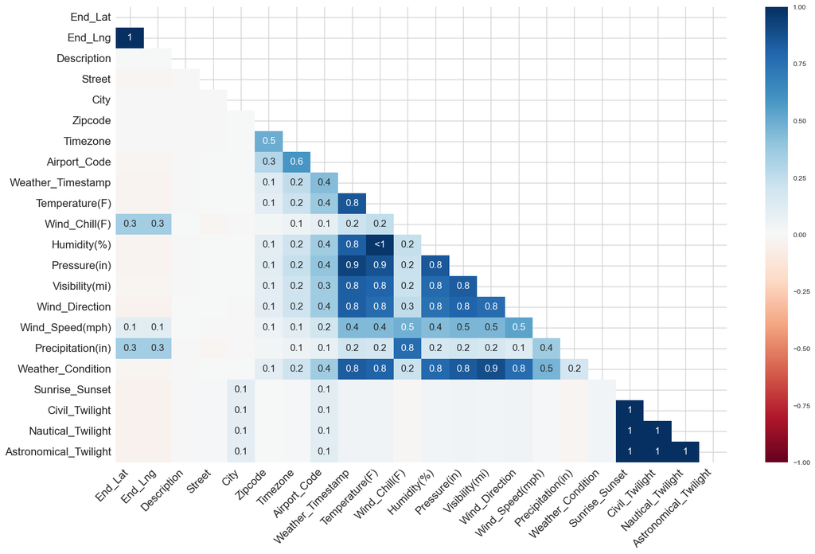

```python
msgno.heatmap(data);
```

Good to know:

- Confirmed that Latitude/Longitude Data are strictly missing together.
- Weather data seems to be missing together in general but not perfectly missing and not a uniform relationship (Precipitation and Wind Direction for example).
- The day/night variables are strictly missing together.

### Ending Coordinates

The simplest solution would be to just setting missing end coordinates to the observation's start coordinates. But is this a common occurence among the observations which none of these variables are missing?

```python
same_startVend = data[(data['Start_Lat']==data['End_Lat']) & (data['Start_Lng']==data['End_Lng'])]

same_startVend.shape[0]/data['End_Lat'].notnull().shape[0]
```

```
0.05147227224698948
```

5% of the observations which have both start & end coordinates. So it is not uncommon but not frequent enough to make me comfortable changing half of the observations.

We have speculated that there is a relationship between distance feature and the coordinates. Let's explore that further to inform our decision to handle missing values.

```python
(same_startVend['Distance(mi)'] > 0).sum()
```

```
0
```

So the distance metric for all of the observations with equal start and end coordinates is 0.

Let's consider the same analysis for those observations missing the end coordinates.

```python
missing_ends = data[data['End_Lat'].isnull()]['Distance(mi)']
missing_ends.describe()
```

```
count   3402762.000
mean          0.212
std           1.637
min           0.000
25%           0.000
50%           0.000
75%           0.000
max         441.750
Name: Distance(mi), dtype: float64
```

```python
(missing_ends==0).sum() / missing_ends.shape[0]
```

```
0.8524513321825035
```

So for a significant portion of the observations missing the end coordinates, the distance metric is also 0.

What does distance for the rest look like?

```python
data[(data['End_Lat'].isnull()) & (data['Distance(mi)'] > 0)]['Distance(mi)'].describe()
```

```
count   502073.000
mean         1.438
std          4.050
min          0.010
25%          0.010
50%          0.010
75%          1.330
max        441.750
Name: Distance(mi), dtype: float64
```

For these observations (especially the large outliers), it does not appear advisable to force the end coordinates to equal the start.

ACTION DECISION: Set all missing ending coordinates equal to their starting coordinates. (Possibility that this feature may ultimately be tossed in the future.)

### Weather

Based on some research and intuition, we can make some decisions on how to handle missing values.

#### Conditions

```python
data.Weather_Condition.isnull().sum()/data.shape[0]
```

```
0.02244437848277404
```

It's only 2% of the data and, as it stands, I have no way have extrapolating how any individual observation should be classified. Therefore, it is probably safe to remove.

ACTION DECISION: Remove all observations missing the Weather Condition feature.

ACTION DECISION: Drop Missing Temperature.

#### Precipitation, Wind Speed & Wind Direction

```python
(data['Precipitation(in)']==0).sum()/data[data['Precipitation(in)'].notnull()].shape[0]
```

```
0.9035097690272675
```

Most (> 90%) of the observations not missing precipitation have 0. So it doesn't seem unreasonable to set missing values to 0. (It may be worthwhile to check against the weather condition in the future.)

ACTION DECISION: Set missing observations of precipitation to 0.

```python
(data['Wind_Speed(mph)']==0).sum()/data[data['Wind_Speed(mph)'].notnull()].shape[0]
```

```
0.1343609568095506
```

While not as frequent, there are plenty (13%) of observations with wind speed equal to 0. So it doesn't seem unreasonable to set missing values to 0. (It may be worthwhile to check against the observations wind direction and/or wind chill in the future.)

ACTION DECISION: Set missing observations of wind speed to 0.

```python
data['Wind_Direction'].value_counts(normalize=True,dropna=False)
```

```
Wind_Direction
CALM       0.124
S          0.054
SSW        0.050
W          0.050
WNW        0.049
NW         0.048
Calm       0.048
SW         0.047
WSW        0.046
SSE        0.045
NNW        0.043
N          0.040
SE         0.038
E          0.036
ESE        0.035
NE         0.033
ENE        0.033
NNE        0.033
VAR        0.032
South      0.023
NaN        0.023
West       0.021
North      0.020
Variable   0.015
East       0.013
Name: proportion, dtype: float64
```

A significant portion of the observations have some equivalent of calm, which I interpet it as 0 wind. So I do not believe it is unreasonable to assume missing values to be the equivalent to 0 wind as well. (Again, it may be worthwhile to check against the other wind features in the future.)

ACTION DECISION: Set missing observtions of wind direction to 'CALM' or some equivalent. (Will depend on how I end up cleaning the Wind_Direction feature.)

##### Wind Chill

```python
data[data['Wind_Chill(F)']==data['Temperature(F)']].shape[0]/data.shape[0]
```

```
0.5731335643602021
```

Over half of the observations occur where there is no additional effect on temp from the wind, so I do not think it is too dangerous to set missing wind-chill values equal to the temperture. (It may be worthwhile to check against the wind speed in the future.)

ACTION DECISION: Set missing values of wind chill to the observation's temperture value.

#### Pressure, Visibility & Humidity

Per this google search https://www.google.com/search?client=safari&rls=en&q=can+air+pressure+be+0&ie=UTF-8&oe=UTF-8, air pressure cannot be 0 (except in a vacuum). So without any anchor value to use, I do not think it wise to assign missing observations to any value.

ACTION DECISION: Remove all observations missing a value for the Pressure feature.

There is also no obvious value to use for visibility.

ACTION DECISION: Remove all observations missing a value for the Pressure feature.

```python
(data['Humidity(%)']==0).sum()/data[data['Humidity(%)'].notnull()].shape[0]
```

```
0.0
```

There are no observations with 0% humidity, so we do not have any reasonable anchor value to use once again.

ACTION DECISION: Remove all observations missing a value for the Humidity feature.

## Duplicates

There are no duplicates to deal with:

```python
if _SPARK_:
    duplicates = int(data.count() - data.dropDuplicates().count())
    duplicates.show()
else:
    print(data.duplicated().sum())
```

```
0
```

Nothing to worry about.

## Outliers

```python
if _SPARK_:
    pass
else:
    print(pd.DataFrame({c:{z:count_outliers(data[c].dropna(),z) for z in [3,5,10,15,20]} for c in _NUMERICS_}).T)
```

```
                       3      5     10    15    20
Severity           204710      0     0     0     0
Distance(mi)       109071  39983  9533  3722  1736
Temperature(F)         74     21     0     0     0
Wind_Chill(F)          34     13     0     0     0
Humidity(%)             0      0     0     0     0
Pressure(in)           89     86    30    30    30
Visibility(mi)      14717  10043  5745  3307   811
Wind_Speed(mph)     56662   3760   229   159   118
Precipitation(in)   20958   8347  1872   860   590
```

Distance seems to be the primary feature in the dataset (lite or full) that has significant outliers.

There are also some extreme weather metrics that will need further exploration.

```python
print(f'{(data['Distance(mi)'] > 100).sum()} of the observations are greater than 100 miles.  Lets drop these')
```

```
86 of the observations are greater than 100 miles.  Lets drop these
```

ACTION DECISION: Drop observations with distance impacted to be over 100 miles.

## High-Level Features

### Nature of Accident

We will eventually create another feature to describe the nature of any accident but for now, we have severity (a discrete variable) and distance.

```python
data['Severity'].value_counts(normalize=True)
```

```
Severity
2   0.797
3   0.168
4   0.026
1   0.009
Name: proportion, dtype: float64
```

We have significant class imbalances. Even though it is unclear what methodology (if any) is used to determine severity, this imbalance makes sense: Low-impact incidents are likely underreported and the highest-impact incidents are, fortunately, rare.

```python
data['Distance(mi)'].value_counts(bins=25,normalize=True).sort_index(ascending=True)
```

```
(-0.443, 17.67]    0.999
(17.67, 35.34]     0.001
(35.34, 53.01]     0.000
(53.01, 70.68]     0.000
(70.68, 88.35]     0.000
(88.35, 106.02]    0.000
(106.02, 123.69]   0.000
(123.69, 141.36]   0.000
(141.36, 159.03]   0.000
(159.03, 176.7]    0.000
(176.7, 194.37]    0.000
(194.37, 212.04]   0.000
(212.04, 229.71]   0.000
(229.71, 247.38]   0.000
(247.38, 265.05]   0.000
(265.05, 282.72]   0.000
(282.72, 300.39]   0.000
(300.39, 318.06]   0.000
(318.06, 335.73]   0.000
(335.73, 353.4]    0.000
(353.4, 371.07]    0.000
(371.07, 388.74]   0.000
(388.74, 406.41]   0.000
(406.41, 424.08]   0.000
(424.08, 441.75]   0.000
Name: proportion, dtype: float64
```

We know from exploring this feature's missing values and outliers what the issues for this feature. The binning makes it seem that there are negative values but this is not the case.

```python
msg = f'{(data['Distance(mi)']==0).sum()/data.shape[0]:.2f} of observations have 0 impact distance and '
msg += f'{(0 > data['Distance(mi)']).sum()} observations with negative impact distance.'

print(msg)
```

```
0.43 of observations have 0 impact distance and 0 observations with negative impact distance.
```

### Time Features

To explore properly, we need to convert to datetime type (from pandas). Also, need to convert into seconds and then into hours.

It is required to set the 'format' parameter to "mixed". (Too many observations to understand why / explore observations setting off the error.)

```python
start = pd.to_datetime(data['Start_Time'],format='mixed')
end = pd.to_datetime(data['End_Time'],format='mixed')
time_change = (end - start).astype('timedelta64[s]').dt.seconds/3600
time_change.describe()
```

```
count   7728394.000
mean          1.813
std           2.099
min           0.000
25%           0.525
50%           1.246
75%           2.077
max          24.000
dtype: float64
```

```python
time_change.value_counts(bins=25,normalize=True).sort_index(ascending=True)
```

```
(-0.025, 0.96]   0.396
(0.96, 1.92]     0.312
(1.92, 2.88]     0.148
(2.88, 3.84]     0.035
(3.84, 4.8]      0.022
(4.8, 5.76]      0.008
(5.76, 6.72]     0.054
(6.72, 7.68]     0.004
(7.68, 8.64]     0.003
(8.64, 9.6]      0.002
(9.6, 10.56]     0.002
(10.56, 11.52]   0.002
(11.52, 12.48]   0.002
(12.48, 13.44]   0.002
(13.44, 14.4]    0.002
(14.4, 15.36]    0.001
(15.36, 16.32]   0.001
(16.32, 17.28]   0.000
(17.28, 18.24]   0.000
(18.24, 19.2]    0.000
(19.2, 20.16]    0.000
(20.16, 21.12]   0.000
(21.12, 22.08]   0.000
(22.08, 23.04]   0.000
(23.04, 24.0]    0.000
Name: proportion, dtype: float64
```

For the most part, this distribution makes sense. Again despite the binning, there are no negative values for the time of impact.

```python
msg = f'{(time_change==0).sum()} of the observations have 0 impact duration and '
msg += f'{(0 > time_change).sum()} observations with negative impact duration.'

print(msg)
```

```
186 of the observations have 0 impact duration and 0 observations with negative impact duration.
```

It is unusual to see that some observations have no duration but it such a small number and purposely possible that it means essentially 0. So no need to stess.

### Address Features

```python
data['Country'].value_counts()
```

```
Country
US    7728394
Name: count, dtype: int64
```

Confirming that all observations are in the USA so we can infact ignore this featue in the future.

ACTION DECISION: Remove column/feature as part of data cleaning.

```python
_USELESS_.extend(['Country'])
```

#### Coordinates

```python
coords_count = data.value_counts(['Start_Lat','Start_Lng'])
coords_count.sort_values(ascending=False).head(25)
```

```
Start_Lat  Start_Lng
37.808     -122.367     570
33.941     -118.097     561
34.859     -82.260      543
42.477     -83.112      534
33.745     -84.390      530
34.859     -82.260      494
40.848     -73.943      473
25.789     -80.204      439
42.368     -83.058      435
25.899     -80.210      432
33.782     -84.391      428
33.876     -118.103     420
40.850     -73.945      418
34.914     -82.107      416
33.822     -84.359      405
25.964     -80.166      402
34.833     -82.297      390
33.950     -118.092     386
44.966     -93.270      384
25.869     -80.208      379
34.859     -82.260      373
34.010     -117.823     372
25.991     -80.166      371
41.063     -73.862      371
33.722     -84.395      365
Name: count, dtype: int64
```

```python
if _LITE_SWITCH_:
    freq_coords = pd.DataFrame(index=coords_count[coords_count > 30].index)
else:
    freq_coords = pd.DataFrame(index=coords_count[coords_count > 250].index)
```

Interesting, there are almost 2k locations where many many accidents have occured. These observations may be useful for analysis.

ACTION DECISION: Create Dataset for observations with overlapping coordinates.

#### State

```python
# Check for bad strings
unclean = data['State'].str.startswith(' ').sum() + data['State'].str.endswith(' ').sum()
unclean
```

```
0
```

There are none to deal with.

```python
data['State'].value_counts(dropna=False,normalize=True)
```

```
State
CA   0.225
FL   0.114
TX   0.075
SC   0.050
NY   0.045
NC   0.044
VA   0.039
PA   0.038
MN   0.025
OR   0.023
AZ   0.022
GA   0.022
IL   0.022
TN   0.022
MI   0.021
LA   0.019
NJ   0.018
MD   0.018
OH   0.015
WA   0.014
AL   0.013
UT   0.013
CO   0.012
OK   0.011
MO   0.010
CT   0.009
IN   0.009
MA   0.008
WI   0.004
KY   0.004
NE   0.004
MT   0.004
IA   0.003
AR   0.003
NV   0.003
KS   0.003
DC   0.002
RI   0.002
MS   0.002
DE   0.002
WV   0.002
ID   0.001
NM   0.001
NH   0.001
WY   0.000
ND   0.000
ME   0.000
VT   0.000
SD   0.000
Name: proportion, dtype: float64
```

California seems very high even adjusting for population and area size. It appears we do not have data from the territories like Puerto Rico (PR), US Virgin Islands (VI) but we do have data from District of Columbia (DC).Comments & Actions. Concerns about balance?

#### City

```python
# Same Double Check
unclean = data['City'].str.startswith(' ').sum() + data['City'].str.endswith(' ').sum()
unclean
```

```
0
```

There are no bad string to deal with.

```python
data['City'].value_counts(dropna=False,normalize=True).sort_values(ascending=False).head(25)
```

```
City
Miami           0.024
Houston         0.022
Los Angeles     0.020
Charlotte       0.018
Dallas          0.017
Orlando         0.014
Austin          0.013
Raleigh         0.011
Nashville       0.009
Baton Rouge     0.009
Atlanta         0.009
Sacramento      0.009
San Diego       0.007
Phoenix         0.007
Minneapolis     0.007
Richmond        0.006
Oklahoma City   0.006
Jacksonville    0.005
Tucson          0.005
Columbia        0.005
San Antonio     0.005
Greenville      0.005
Saint Paul      0.005
Seattle         0.005
Portland        0.005
Name: proportion, dtype: float64
```

No concerns with balance (or over-representation). Interesting to see some of these cities make it in the top 25.

#### Zipcode

```python
unclean = data['Zipcode'].str.startswith(' ').sum() + data['Zipcode'].str.endswith(' ').sum()
unclean
```

```
0
```

No issues.

```python
data['Zipcode'].value_counts(dropna=False,normalize=True).sort_values(ascending=False)
```

```
Zipcode
91761        0.001
91706        0.001
92407        0.001
92507        0.001
33186        0.001
              ...
95829-9419   0.000
23464-8533   0.000
33187-1958   0.000
32606-5861   0.000
94401-2213   0.000
Name: proportion, Length: 825095, dtype: float64
```

Like with city, there doesn't appear to be any concern with the balance. The syntax with the 4-digit extension (used to tell delivery system a more specific location) should probably be removed since we want consistency.

ACTION DECISION: Force all zipcodes to follow simple five digit syntax.

```python
data['Zipcode'].str.contains(r'[0-9]{5}').sum()
```

```
7726479
```

#### Airport Code

```python
unclean = data['Airport_Code'].str.startswith(' ').sum() + data['Airport_Code'].str.endswith(' ').sum()
unclean
```

```
0
```

No issue.

```python
data['Airport_Code'].value_counts(dropna=False,normalize=True).sort_values(ascending=False)
```

```
Airport_Code
KCQT   0.015
KRDU   0.014
KMCJ   0.013
KBNA   0.013
KCLT   0.013
        ...
KIEN   0.000
K8D3   0.000
KAVK   0.000
KY22   0.000
KICR   0.000
Name: proportion, Length: 2046, dtype: float64
```

The distribution itslef isn't necessarily a concern. However, these codes do not make much sense. If KCQT is actually a code for an airport, it would be refering to Seattle (WA) and KRDU would be refering to the airport in Raleigh-Durham (NC). The latter especialy would be surprising from common sense. Where is LAX?

```python
lax_count = data[data['Airport_Code']=='LAX'].shape[0]
print(f'There are {lax_count} incidents with LAX as its airport code.')
```

```
There are 0 incidents with LAX as its airport code.
```

Upon further review, this may be indication that this feature is not the traditional airport codes but weather stations! If that is the case, this feature would have limited analytical value (for now).

ACTION DECISION: Remove this feature from the dataset.

```python
_USELESS_.extend(['Airport_Code'])
```

#### Timezone

```python
data['Timezone'].value_counts(normalize=True,dropna=False)
```

```
Timezone
US/Eastern    0.463
US/Pacific    0.267
US/Central    0.213
US/Mountain   0.056
NaN           0.001
Name: proportion, dtype: float64
```

No information can be gleaned from this feature. I will be grouping the states later on but in ways that either make sense for analytics or for "real-life" recommendations.

ACTION DECISION: Remove this feature from the dataset.

```python
_USELESS_.extend(['Timezone'])
```

#### Street Type

```python
unclean = data['Street'].str.startswith(' ').sum() + data['Street'].str.endswith(' ').sum()
unclean
```

```
1696520
```

Actually need to handle this if we are to use this feature and need to make sure it is handled in data processing stage.

```python
streets = data['Street'].str.strip()
unclean = streets.str.startswith(' ').sum() + streets.str.endswith(' ').sum()
unclean
```

```
0
```

Simple fix.

ACTION DECISION: Strip the string feature in data processing.

```python
streets.value_counts(dropna=False,normalize=True).sort_values(ascending=False).head(25)
```

```
Street
I-95 N     0.010
I-95 S     0.010
I-5 N      0.009
I-10 E     0.007
I-10 W     0.007
I-5 S      0.007
I-80 W     0.005
I-80 E     0.005
I-405 N    0.004
I-75 N     0.004
I-75 S     0.004
I-90 E     0.003
I-15 N     0.003
I-94 W     0.003
I-90 W     0.003
US-101 N   0.003
I-95       0.003
I-94 E     0.003
I-70 E     0.003
I-15 S     0.002
I-40 W     0.002
I-84 E     0.002
I-35 N     0.002
I-405 S    0.002
I-40 E     0.002
Name: proportion, dtype: float64
```

Not surprising. We may want to use this information in feature engineering below.

Need to figure out if there is a consistent syntax for street address.

We are going to use the following resources to consider if we can group these observations based on the street name where the accident is reported to have occured.

**Google** on the difference between US numbered highways and US interstate highway system

**[More granular website](https://99percentinvisible.org/article/beyond-streets-avenues-simple-visual-guide-different-types-roads/)**

Federal Roads. Highways & Interstates

```python
highways = streets.str.startswith('US').sum() + streets.str.startswith('United States').sum()

interstates = streets.str.startswith('I-').sum() + streets.str.startswith('Interstate').sum()

fed_roads = highways + interstates

msg = f'There are roughly {fed_roads} incidents which occured on a federal roads:  '
msg += f'{highways} on a numbered highways and {interstates} interstates.'

print(msg)
```

```
There are roughly 2203298 incidents which occured on a federal roads:  275448 on a numbered highways and 1927850 interstates.
```

ACTION DECISION: Create feature 'Federal' to flag these 2.2m+ accidents.

```python
highways = streets.str.startswith('US') | streets.str.startswith('United States')
interstates = streets.str.startswith('I-') | streets.str.startswith('Interstate')
fed_roads = highways | interstates
```

```python
highways = streets[streets.str.contains('Highway',na=False)]
highways.value_counts(dropna=False,normalize=True).sort_values(ascending=False)
```

```
Street
Pearl Harbor Memorial Highway   0.014
Highway 101                     0.013
US Highway 19 N                 0.012
Highway 20                      0.012
US Highway 1                    0.010
                                 ...
652-838 State Highway 299       0.000
641-408 State Highway 299 E     0.000
State Highway 102               0.000
US Highway 425 N                0.000
GA Highway 133 N                0.000
Name: proportion, Length: 5388, dtype: float64
```

Routes

```python
routes = streets[streets.str.startswith('Rt',na=False) | streets.str.startswith('Route',na=False)]
print(routes.shape[0])
routes.value_counts(dropna=False,normalize=True).sort_values(ascending=False)
```

```
16323
```

```
Street
Route 9      0.098
Route 22     0.051
Route 6      0.045
Route 146    0.027
Route 82     0.026
              ...
Route 872    0.000
Route 74 E   0.000
Route 129    0.000
Route 547    0.000
Route 426    0.000
Name: proportion, Length: 405, dtype: float64
```

```python
routes = streets.str.startswith('Route').sum() + streets.str.startswith('Rt').sum()
routes
```

```
16323
```

### Weather

#### Quantitative Features

```python
weather_factors = ['Temperature(F)','Wind_Chill(F)',
                   'Humidity(%)','Pressure(in)',
                   'Visibility(mi)','Wind_Speed(mph)',
                   'Precipitation(in)']

data[weather_factors].describe()
```

|  | Temperature(F) | Wind_Chill(F) | Humidity(%) | Pressure(in) | Visibility(mi) | Wind_Speed(mph) | Precipitation(in) |
| --- | --- | --- | --- | --- | --- | --- | --- |
| count | 7564541.000 | 5729375.000 | 7554250.000 | 7587715.000 | 7551296.000 | 7157161.000 | 5524808.000 |
| mean | 61.663 | 58.251 | 64.831 | 29.539 | 9.090 | 7.685 | 0.008 |
| std | 19.014 | 22.390 | 22.821 | 1.006 | 2.688 | 5.425 | 0.110 |
| min | -89.000 | -89.000 | 1.000 | 0.000 | 0.000 | 0.000 | 0.000 |
| 25% | 49.000 | 43.000 | 48.000 | 29.370 | 10.000 | 4.600 | 0.000 |
| 50% | 64.000 | 62.000 | 67.000 | 29.860 | 10.000 | 7.000 | 0.000 |
| 75% | 76.000 | 75.000 | 84.000 | 30.030 | 10.000 | 10.400 | 0.000 |
| max | 207.000 | 207.000 | 100.000 | 58.630 | 140.000 | 1087.000 | 36.470 |

#### Categorical Features

```python
weather_descriptions = data['Weather_Condition'].unique()
print(f'There are {weather_descriptions.shape[0]} ways that the weather is described in this dataset: \n')
print(weather_descriptions)
```

```
There are 145 ways that the weather is described in this dataset:

['Light Rain' 'Overcast' 'Mostly Cloudy' 'Rain' 'Light Snow' 'Haze'
 'Scattered Clouds' 'Partly Cloudy' 'Clear' 'Snow'
 'Light Freezing Drizzle' 'Light Drizzle' 'Fog' 'Shallow Fog' 'Heavy Rain'
 'Light Freezing Rain' 'Cloudy' 'Drizzle' nan 'Light Rain Showers' 'Mist'
 'Smoke' 'Patches of Fog' 'Light Freezing Fog' 'Light Haze'
 'Light Thunderstorms and Rain' 'Thunderstorms and Rain' 'Fair'
 'Volcanic Ash' 'Blowing Sand' 'Blowing Dust / Windy' 'Widespread Dust'
 'Fair / Windy' 'Rain Showers' 'Mostly Cloudy / Windy'
 'Light Rain / Windy' 'Hail' 'Heavy Drizzle' 'Showers in the Vicinity'
 'Thunderstorm' 'Light Rain Shower' 'Light Rain with Thunder'
 'Partly Cloudy / Windy' 'Thunder in the Vicinity' 'T-Storm'
 'Heavy Thunderstorms and Rain' 'Thunder' 'Heavy T-Storm' 'Funnel Cloud'
 'Heavy T-Storm / Windy' 'Blowing Snow' 'Light Thunderstorms and Snow'
 'Heavy Snow' 'Low Drifting Snow' 'Light Ice Pellets' 'Ice Pellets'
 'Squalls' 'N/A Precipitation' 'Cloudy / Windy' 'Light Fog' 'Sand'
 'Snow Grains' 'Snow Showers' 'Heavy Thunderstorms and Snow'
 'Rain / Windy' 'Heavy Rain / Windy' 'Heavy Ice Pellets'
 'Light Snow / Windy' 'Heavy Freezing Rain' 'Small Hail'
 'Heavy Rain Showers' 'Thunder / Windy' 'Drizzle and Fog'
 'T-Storm / Windy' 'Blowing Dust' 'Smoke / Windy' 'Haze / Windy' 'Tornado'
 'Light Drizzle / Windy' 'Widespread Dust / Windy' 'Wintry Mix'
 'Wintry Mix / Windy' 'Light Snow with Thunder' 'Fog / Windy'
 'Snow and Thunder' 'Light Snow Shower' 'Sleet' 'Light Snow and Sleet'
 'Snow / Windy' 'Rain Shower' 'Snow and Sleet' 'Light Sleet'
 'Heavy Snow / Windy' 'Freezing Drizzle' 'Light Freezing Rain / Windy'
 'Thunder / Wintry Mix' 'Blowing Snow / Windy' 'Freezing Rain'
 'Light Snow and Sleet / Windy' 'Snow and Sleet / Windy' 'Sleet / Windy'
 'Heavy Freezing Rain / Windy' 'Squalls / Windy'
 'Light Rain Shower / Windy' 'Snow and Thunder / Windy'
 'Light Sleet / Windy' 'Sand / Dust Whirlwinds' 'Mist / Windy'
 'Drizzle / Windy' 'Duststorm' 'Sand / Dust Whirls Nearby'
 'Thunder and Hail' 'Heavy Sleet' 'Freezing Rain / Windy'
 'Light Snow Shower / Windy' 'Partial Fog' 'Thunder / Wintry Mix / Windy'
 'Patches of Fog / Windy' 'Rain and Sleet' 'Light Snow Grains'
 'Partial Fog / Windy' 'Sand / Dust Whirlwinds / Windy'
 'Heavy Snow with Thunder' 'Light Snow Showers' 'Heavy Blowing Snow'
 'Light Hail' 'Heavy Smoke' 'Heavy Thunderstorms with Small Hail'
 'Light Thunderstorm' 'Heavy Freezing Drizzle' 'Light Blowing Snow'
 'Thunderstorms and Snow' 'Dust Whirls' 'Rain Shower / Windy'
 'Sleet and Thunder' 'Heavy Sleet and Thunder' 'Drifting Snow / Windy'
 'Shallow Fog / Windy' 'Thunder and Hail / Windy' 'Heavy Sleet / Windy'
 'Sand / Windy' 'Heavy Rain Shower / Windy' 'Blowing Snow Nearby'
 'Heavy Rain Shower' 'Drifting Snow']
```

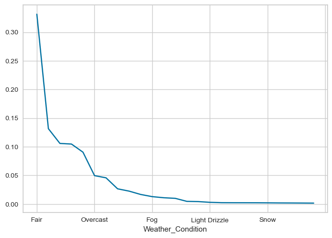

```python
weather_desc_counts = data['Weather_Condition'].value_counts(dropna=False,normalize=True)
weather_desc_counts.sort_values(ascending=False).head(25).plot()
```

This weather condition feature is too granular to be of any analytical value. We need to consider consolidating this feature or ignore it all together. May be of interest to consider how these categories relate to the numeric weather features.

### Night/Day Features

There appears to be multiple indicators for day/night that need to be explored. According to **Google**, Nautical, Astronomical and Civil all have precise definitions--based on usage--that do not, to me, inform as to how their distinctions contribute to understanding accident patterns.

```python
print(pd.crosstab(data['Nautical_Twilight'],data['Astronomical_Twilight']))
print('-'*50)
print(pd.crosstab(data['Nautical_Twilight'],data['Civil_Twilight']))
print('-'*50)
print(pd.crosstab(data['Nautical_Twilight'],data['Sunrise_Sunset']))
```

```
Astronomical_Twilight      Day    Night
Nautical_Twilight
Day                    6070128     6028
Night                   307420  1321572
--------------------------------------------------
Civil_Twilight         Day    Night
Nautical_Twilight
Day                5695619   380537
Night                    0  1628992
--------------------------------------------------
Sunrise_Sunset         Day    Night
Nautical_Twilight
Day                5334553   741603
Night                    0  1628992
```

```python
print(pd.crosstab(data['Astronomical_Twilight'],data['Civil_Twilight']))
print('-'*50)
print(pd.crosstab(data['Astronomical_Twilight'],data['Sunrise_Sunset']))
```

```
Civil_Twilight             Day    Night
Astronomical_Twilight
Day                    5689968   687580
Night                     5651  1321949
--------------------------------------------------
Sunrise_Sunset             Day    Night
Astronomical_Twilight
Day                    5329105  1048443
Night                     5448  1322152
```

```python
print(pd.crosstab(data['Civil_Twilight'],data['Sunrise_Sunset']))
```

```
Sunrise_Sunset      Day    Night
Civil_Twilight
Day             5334473   361146
Night                80  2009449
```

Ultimately, I think dropping all of them except for Sunrise_Sunset is for the best.

ACTION DECISION: Remove Nautical_Twilight, Civil_Twilight, Astronomical_Twilight and leave Sunrise_Sunse.

```python
_USELESS_.extend(['Nautical_Twilight','Civil_Twilight','Astronomical_Twilight'])
```

### Infrastructure

```python
infrastructures = ['Amenity','Bump','Crossing','Give_Way',
                   'Junction','No_Exit','Railway','Roundabout',
                   'Station','Stop','Traffic_Calming','Traffic_Signal',
                   'Turning_Loop'
                   ]
```

Need to verify what the definitions of each of these are...

```python
data[infrastructures].sum().sort_values(ascending=False)/data.shape[0]
```

```
Traffic_Signal    0.148
Crossing          0.113
Junction          0.074
Stop              0.028
Station           0.026
Amenity           0.012
Railway           0.009
Give_Way          0.005
No_Exit           0.003
Traffic_Calming   0.001
Bump              0.000
Roundabout        0.000
Turning_Loop      0.000
dtype: float64
```

Not surprising. Although, we need to look at overlap to get a better picture.

How often do these overlap?

```python
full_range = range(0,len(infrastructures))
print('The number of observations where X infrastructure types are found.')
data[infrastructures].sum(axis=1).value_counts().reindex(full_range,fill_value=0)
```

```
The number of observations where X infrastructure types are found.
```

```
0     5427044
1     1543182
2      609259
3      124709
4       21086
5        2907
6         205
7           2
8           0
9           0
10          0
11          0
12          0
Name: count, dtype: int64
```

Overwhelming majority have no such infrastructures.

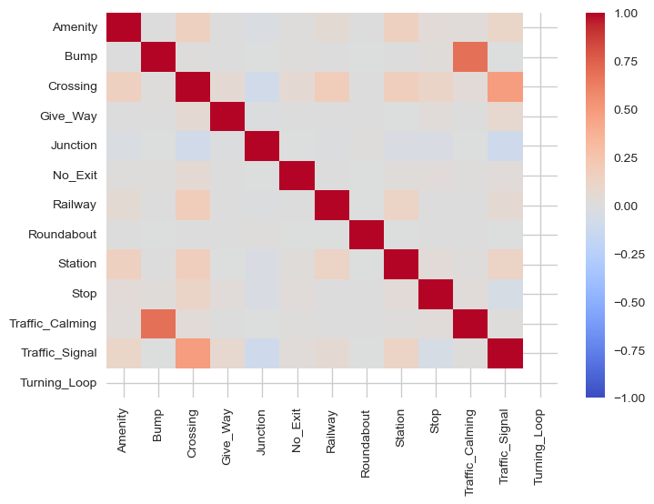

```python
sns.heatmap(data[infrastructures].corr(),vmin=-1,vmax=1,cmap='coolwarm');
```

This doesn't really tell us anything since we only have data from when accidents occur. We will want to instead focus on the nature of the accidents and if the existence of any one (or more) reduces the severity, etc.

# 3-Data Processing

Start with a brand new dataset

```python
del data
if _SPARK_:
    spark.stop()
else:
    pass
```

```python
if _SPARK_:
    spark = SparkSession.builder.appName("Accident Data Project").getOrCreate()
    data_clean = spark.read.csv('US_Accidents_March23.csv',header=True,inferSchema=True)
else:
    if _LITE_SWITCH_:
        data_clean = pd.read_csv('US_Accidents_March23_sampled_500k.csv',index_col=0)
    else:
        data_clean = pd.read_csv('US_Accidents_March23.csv',index_col=0)
```

```python
if _SPARK_:
    N = data_clean.count()
    D = len(data_clean.columns)
else:
    N = data_clean.shape[1]
    D = data_clean.shape[0]
```

```python
if _SPARK_:
    data_clean.printSchema()
else:
    data_clean.info()

print("Features: ",D)
print("Entries:  ",N)
```

```
<class 'pandas.core.frame.DataFrame'>
Index: 7728394 entries, A-1 to A-7777761
Data columns (total 45 columns):
 #   Column                 Dtype
---  ------                 -----
 0   Source                 object
 1   Severity               int64
 2   Start_Time             object
 3   End_Time               object
 4   Start_Lat              float64
 5   Start_Lng              float64
 6   End_Lat                float64
 7   End_Lng                float64
 8   Distance(mi)           float64
 9   Description            object
```

[output cut: 39 more lines]

## Drop Unnecessary Columns

Based on prior exploratory work.

```python
print(len(_USELESS_))
print('Going forward, I am completely removing the following features' +' '.join(_USELESS_) + '.')
```

```
8
Going forward, I am completely removing the following featuresSource Weather_Timestamp Country Airport_Code Timezone Nautical_Twilight Civil_Twilight Astronomical_Twilight.
```

```python
data_clean = data_clean.drop(_USELESS_,axis=1)
```

## Missing Data

### End Coordinates

```python
data_clean['End_Lat'] = data_clean['End_Lat'].fillna(data_clean['Start_Lat'])
data_clean['End_Lng'] = data_clean['End_Lng'].fillna(data_clean['Start_Lng'])
```

### Weather

```python
drop_missing = ['Weather_Condition','Temperature(F)','Pressure(in)','Visibility(mi)','Humidity(%)']
data_clean = data_clean.dropna(subset = drop_missing)
```

```python
data_clean['Precipitation(in)'] = data_clean['Precipitation(in)'].fillna(0)
data_clean['Wind_Speed(mph)'] = data_clean['Wind_Speed(mph)'].fillna(0)
data_clean['Wind_Direction'] = data_clean['Wind_Direction'].fillna('CALM')
```

```python
data_clean['Wind_Chill(F)'] = data_clean['Wind_Chill(F)'].fillna(data_clean['Temperature(F)'])
```

### Description

```python
# For now...
data_clean = data_clean.dropna(subset = ['Description'])
```

### Address

```python
# For now...
data_clean = data_clean.dropna(subset = ['Street','Zipcode','City'])
```

### Day/Night

```python
# For now...
data_clean = data_clean.dropna(subset = ['Sunrise_Sunset'])
```

## Outliers

```python
condition = data_clean['Distance(mi)'] > 100
data_clean = data_clean[~condition]
```

## Data Cleaning

```python
data_clean['Street'] = data_clean['Street'].str.strip()
```

```python
data_clean['Zipcode'] = data_clean['Zipcode'].str.extract(r'([0-9]{5})')
```

## Feature Engineering

### Impact Duration

```python
if _SPARK_:
    pass
else:
    data_clean['Start'] = pd.to_datetime(data_clean['Start_Time'],format='mixed')
    data_clean['End'] = pd.to_datetime(data_clean['End_Time'],format='mixed')
```

And create a new target feature describing the nature of the accident as a function of time.

```python
data_clean['Time_of_Impact(hr)'] = (data_clean['End'] - data_clean['Start']).dt.seconds/3600
```

```python
data_clean['Time_of_Impact(hr)'].describe()
```

```
count   7461589.000
mean          1.809
std           2.099
min           0.000
25%           0.520
50%           1.245
75%           2.074
max          24.000
Name: Time_of_Impact(hr), dtype: float64
```

```python
data_clean = data_clean.drop(['Start_Time','End_Time'],axis=1)
```

### Partition the time data

```python
if _SPARK_:
    pass
else:
    data_clean['Month'] = data_clean['Start'].dt.month
    data_clean['Year'] = data_clean['Start'].dt.year
    data_clean['DayofYear'] = data_clean['Start'].dt.dayofyear
    data_clean['DayofMonth'] = data_clean['Start'].dt.day
    data_clean['DayofWeek'] = data_clean['Start'].dt.day_of_week
    data_clean['Quarter'] = data_clean['Start'].dt.quarter
    data_clean['Hour'] = data_clean['Start'].dt.hour
    data_clean['Date'] = data_clean['Start'].dt.date
```

### Explore these new features...

```python
data_clean['Year'].value_counts(normalize=True).sort_index()
```

```
Year
2016   0.053
2017   0.093
2018   0.116
2019   0.125
2020   0.153
2021   0.203
2022   0.226
2023   0.032
Name: proportion, dtype: float64
```

Concering the book end years are so under represented. Consider removing entirely?

```python
data_clean['Quarter'].value_counts(normalize=True)
```

```
Quarter
4   0.295
1   0.254
3   0.228
2   0.223
Name: proportion, dtype: float64
```

```python
data_clean['Month'].value_counts(normalize=True).sort_index()
```

```
Month
1    0.097
2    0.085
3    0.072
4    0.076
5    0.073
6    0.074
7    0.066
8    0.078
9    0.084
10   0.088
11   0.098
12   0.109
Name: proportion, dtype: float64
```

```python
data_clean['DayofWeek'].value_counts(normalize=True).sort_index()
```

```
DayofWeek
0   0.157
1   0.167
2   0.170
3   0.171
4   0.177
5   0.086
6   0.072
Name: proportion, dtype: float64
```

```python
data_clean['Hour'].value_counts(normalize=True).sort_index()
```

```
Hour
0    0.014
1    0.012
2    0.012
3    0.011
4    0.021
5    0.029
6    0.052
7    0.076
8    0.075
9    0.047
10   0.044
11   0.046
12   0.046
13   0.051
14   0.058
15   0.068
16   0.076
17   0.075
18   0.056
19   0.038
20   0.029
21   0.025
22   0.022
23   0.016
Name: proportion, dtype: float64
```

### Weekend

```python
data_clean['Weekend'] = ((data_clean['DayofWeek'] == 5) | (data_clean['DayofWeek'] == 6))
```

```python
print(f'There are {data_clean['Weekend'].sum()} observations which occured over the weekend.')
data_clean.groupby('Weekend')['Severity'].mean()
```

```
There are 1175902 observations which occured over the weekend.
```

```
Weekend
False   2.204
True    2.249
Name: Severity, dtype: float64
```

### Holidays

Per **[Google](https://www.google.com/search?client=safari&rls=en&q=holidays+with+most+traffic&ie=UTF-8&oe=UTF-8)**, there are a number of holidays in the US with the highest amount of traffic. (I subbed NYE in for XMas.)

```python
thanksgivings = [get_thanksgiving_date(y) for y in range(2016,2024)]
memorials = [calculate_memorial_day(y) for y in range(2016,2024)]
labors = [get_labor_day(y) for y in range(2016,2024)]
```

```python
july_4 = ((data_clean['Month'] == 7) & (data_clean['DayofMonth'] == 4))
thanksgiving = data_clean['Date'].apply(lambda d:d in thanksgivings)
memorial = data_clean['Date'].apply(lambda d:d in memorials)
labor = data_clean['Date'].apply(lambda d:d in labors)
nye = ((data_clean['Month'] == 12) & (data_clean['DayofMonth'] == 31))
```

```python
holidays = (july_4 | thanksgiving | memorial | labor | nye)
data_clean['Holiday'] = holidays
```

```python
info = f'''{holidays.sum()} incidents occured on a prime holiday.'''

print(info)
```

```
74954 incidents occured on a prime holiday.
```

### Rush Hour Indicator

**[Per Google:](https://www.google.com/search?client=safari&rls=en&q=rush+hour+typically&ie=UTF-8&oe=UTF-8)** The morning rush hour begins around 6a, peaking between 7a & 9a, and eases off by 10a. While afternoon/evening rush hour begins around 3p, peaking between 4p and 6p, and eases off by 7p.

```python
data_clean['Morning_Rush'] = ((6 > data_clean['DayofWeek']) & (data_clean['DayofWeek'] > 0) & (data_clean['Start'].dt.hour >= 6) & (10 >= data_clean['Start'].dt.hour))
```

```python
print(f'Total of {data_clean['Morning_Rush'].sum()} incidents during the morning rush hour')
```

```
Total of 1728977 incidents during the morning rush hour
```

```python
data_clean['Evening_Rush'] = ((6 > data_clean['DayofWeek']) & (data_clean['DayofWeek'] > 0) & (data_clean['Start'].dt.hour >= 15) & (19 >= data_clean['Start'].dt.hour))
```

```python
print(f'Total of {data_clean['Evening_Rush'].sum()} incidents during the evening rush hour')
```

```
Total of 1823851 incidents during the evening rush hour
```

```python
data_clean['Rush_Hour'] = data_clean['Evening_Rush'] | data_clean['Morning_Rush']
```

### Attach Location-Based Data to DF

Resources

https://www.faa.gov/air_traffic/publications/atpubs/cnt_html/appendix_a.html

https://apps.bea.gov/regional/geography.htm

https://en.wikipedia.org/wiki/List_of_regions_of_the_United_States

https://www2.census.gov/geo/pdfs/reference/GARM/Ch6GARM.pdf

https://en.wikipedia.org/wiki/Megaregions_of_the_United_States

```python
df = pd.read_csv('States.csv')
data_clean = data_clean.join(df.set_index('Abbreviation'),on='State',rsuffix='_Full')
del df
data_clean
```

| ID | Severity | Start_Lat | Start_Lng | End_Lat | End_Lng | Distance(mi) | Description | Street | City | County | State | Zipcode | Temperature(F) | Wind_Chill(F) | Humidity(%) | Pressure(in) | Visibility(mi) | Wind_Direction | Wind_Speed(mph) | Precipitation(in) | Weather_Condition | Amenity | Bump | Crossing | Give_Way | Junction | No_Exit | Railway | Roundabout | … |
| --- | --- | --- | --- | --- | --- | --- | --- | --- | --- | --- | --- | --- | --- | --- | --- | --- | --- | --- | --- | --- | --- | --- | --- | --- | --- | --- | --- | --- | --- | --- |
| A-1 | 3 | 39.865 | -84.059 | 39.865 | -84.059 | 0.010 | Right lane blocked due to accident on I-70 Eas... | I-70 E | Dayton | Montgomery | OH | 45424 | 36.900 | 36.900 | 91.000 | 29.680 | 10.000 | Calm | 0.000 | 0.020 | Light Rain | False | False | False | False | False | False | False | False | … |
| A-2 | 2 | 39.928 | -82.831 | 39.928 | -82.831 | 0.010 | Accident on Brice Rd at Tussing Rd. Expect del... | Brice Rd | Reynoldsburg | Franklin | OH | 43068 | 37.900 | 37.900 | 100.000 | 29.650 | 10.000 | Calm | 0.000 | 0.000 | Light Rain | False | False | False | False | False | False | False | False | … |
| A-3 | 2 | 39.063 | -84.033 | 39.063 | -84.033 | 0.010 | Accident on OH-32 State Route 32 Westbound at ... | State Route 32 | Williamsburg | Clermont | OH | 45176 | 36.000 | 33.300 | 100.000 | 29.670 | 10.000 | SW | 3.500 | 0.000 | Overcast | False | False | False | False | False | False | False | False | … |
| A-4 | 3 | 39.748 | -84.206 | 39.748 | -84.206 | 0.010 | Accident on I-75 Southbound at Exits 52 52B US... | I-75 S | Dayton | Montgomery | OH | 45417 | 35.100 | 31.000 | 96.000 | 29.640 | 9.000 | SW | 4.600 | 0.000 | Mostly Cloudy | False | False | False | False | False | False | False | False | … |
| A-5 | 2 | 39.628 | -84.188 | 39.628 | -84.188 | 0.010 | Accident on McEwen Rd at OH-725 Miamisburg Cen... | Miamisburg Centerville Rd | Dayton | Montgomery | OH | 45459 | 36.000 | 33.300 | 89.000 | 29.650 | 6.000 | SW | 3.500 | 0.000 | Mostly Cloudy | False | False | False | False | False | False | False | False | … |
| ... | ... | ... | ... | ... | ... | ... | ... | ... | ... | ... | ... | ... | ... | ... | ... | ... | ... | ... | ... | ... | ... | ... | ... | ... | ... | ... | ... | ... | ... | … |
| A-7777757 | 2 | 34.002 | -117.379 | 33.999 | -117.371 | 0.543 | At Market St - Accident. | Pomona Fwy E | Riverside | Riverside | CA | 92501 | 86.000 | 86.000 | 40.000 | 28.920 | 10.000 | W | 13.000 | 0.000 | Fair | False | False | False | False | False | False | False | False | … |
| A-7777758 | 2 | 32.767 | -117.148 | 32.766 | -117.154 | 0.338 | At Camino Del Rio/Mission Center Rd - Accident. | I-8 W | San Diego | San Diego | CA | 92108 | 70.000 | 70.000 | 73.000 | 29.390 | 10.000 | SW | 6.000 | 0.000 | Fair | False | False | False | False | False | False | False | False | … |
| A-7777759 | 2 | 33.775 | -117.848 | 33.777 | -117.857 | 0.561 | At Glassell St/Grand Ave - Accident. in the ri... | Garden Grove Fwy | Orange | Orange | CA | 92866 | 73.000 | 73.000 | 64.000 | 29.740 | 10.000 | SSW | 10.000 | 0.000 | Partly Cloudy | False | False | False | False | True | False | False | False | … |
| A-7777760 | 2 | 33.992 | -118.403 | 33.983 | -118.396 | 0.772 | At CA-90/Marina Fwy/Jefferson Blvd - Accident. | San Diego Fwy S | Culver City | Los Angeles | CA | 90230 | 71.000 | 71.000 | 81.000 | 29.620 | 10.000 | SW | 8.000 | 0.000 | Fair | False | False | False | False | False | False | False | False | … |
| A-7777761 | 2 | 34.134 | -117.231 | 34.137 | -117.239 | 0.537 | At Highland Ave/Arden Ave - Accident. | CA-210 W | Highland | San Bernardino | CA | 92346 | 79.000 | 79.000 | 47.000 | 28.630 | 7.000 | SW | 7.000 | 0.000 | Fair | False | False | False | False | False | False | False | False | … |

7461589 rows × 56 columns

```python
data_clean['AA_Region'] = data_clean['Agency Admin Region']
data_clean['BEA_Region'] = data_clean['Bureau of Economic Analysis']

data_clean = data_clean.drop(['Agency Admin Region','Bureau of Economic Analysis'],axis=1)
```

### Consider Street Type Feature(s)

```python
streets = data_clean['Street']
```

#### Federal Roads

```python
highways = streets.str.startswith('US') | streets.str.startswith('United States')
interstates = streets.str.startswith('I-') | streets.str.startswith('Interstate')
data_clean['Federal'] = highways | interstates
```

#### Bridges

```python
bridges = (streets.str.contains('Bridge') | streets.str.contains('BRIDGE') |
           streets.str.contains('Brg') | streets.str.contains('BRG') |
           streets.str.contains('Br') | streets.str.contains('BR')
           )
```

```python
data_clean['Bridge'] = bridges
```

## Create State/Commute Dataframe

```python
df1 = data_clean.groupby(['State_Full','Year'])[['Severity','Time_of_Impact(hr)','Distance(mi)']].mean()
df2 = data_clean.value_counts(['State_Full','Year'])
print(df1.shape,df2.shape)
df3 = df1.join(df2)
print(df3.shape)
df4 =all_commutes.set_index(['NAME','Year'])
print(df4.shape)
state_commute = df3.join(df4,on=['State_Full','Year'])
state_commute
```

```
(388, 3) (388,)
(388, 4)
(416, 13)
```

| State_Full | Year | Severity | Time_of_Impact(hr) | Distance(mi) | count | DriveAlone | Carpool | Bus | Subway | LongDistanceRail | LightRail | Taxi | Motorcycle | Bicycle | Walked | Other | WorkFromHome | Ferry |
| --- | --- | --- | --- | --- | --- | --- | --- | --- | --- | --- | --- | --- | --- | --- | --- | --- | --- | --- |
| Alabama | 2016 | 2.725 | 6.000 | 1.560 | 131 | 0.861 | 0.080 | 0.003 | 0.000 | 0.000 | 0.000 | 0.001 | 0.001 | 0.001 | 0.012 | 0.007 | 0.033 | 0.000 |
|  | 2017 | 2.588 | 1.804 | 0.333 | 2852 | 0.857 | 0.085 | 0.003 | 0.000 | 0.000 | 0.000 | 0.001 | 0.001 | 0.001 | 0.012 | 0.007 | 0.034 | 0.000 |
|  | 2018 | 2.413 | 0.753 | 0.184 | 13910 | 0.863 | 0.079 | 0.003 | 0.000 | 0.000 | 0.000 | 0.000 | 0.001 | 0.001 | 0.011 | 0.008 | 0.035 | 0.000 |
|  | 2019 | 2.273 | 1.147 | 0.167 | 18974 | 0.852 | 0.087 | 0.004 | 0.000 | 0.000 | 0.000 | 0.001 | 0.001 | 0.001 | 0.012 | 0.008 | 0.034 | 0.000 |
|  | 2020 | 2.219 | 1.656 | 0.576 | 19520 | 0.852 | 0.087 | 0.004 | 0.000 | 0.000 | 0.000 | 0.001 | 0.001 | 0.001 | 0.012 | 0.008 | 0.034 | 0.000 |
| ... | ... | ... | ... | ... | ... | ... | ... | ... | ... | ... | ... | ... | ... | ... | ... | ... | ... | ... |
| Wyoming | 2019 | 3.140 | 0.835 | 11.344 | 107 | 0.769 | 0.115 | 0.012 | 0.000 | 0.000 | 0.000 | 0.000 | 0.002 | 0.010 | 0.030 | 0.005 | 0.057 | 0.000 |
|  | 2020 | 3.231 | 1.686 | 13.659 | 26 | 0.769 | 0.115 | 0.012 | 0.000 | 0.000 | 0.000 | 0.000 | 0.002 | 0.010 | 0.030 | 0.005 | 0.057 | 0.000 |
|  | 2021 | 2.225 | 2.058 | 2.812 | 703 | 0.759 | 0.092 | 0.008 | 0.000 | 0.000 | 0.000 | 0.000 | 0.001 | 0.008 | 0.034 | 0.009 | 0.089 | 0.000 |
|  | 2022 | 2.208 | 1.912 | 3.253 | 1729 | 0.762 | 0.082 | 0.009 | 0.000 | 0.000 | 0.000 | 0.000 | 0.003 | 0.009 | 0.035 | 0.008 | 0.091 | 0.000 |
|  | 2023 | 2.219 | 1.816 | 1.955 | 301 | 0.728 | 0.105 | 0.010 | 0.000 | 0.000 | 0.000 | 0.001 | 0.001 | 0.009 | 0.034 | 0.009 | 0.102 | 0.001 |

388 rows × 17 columns

```python
state_commute['Non-Car'] = state_commute['Motorcycle'] + state_commute['Walked'] + state_commute['Bicycle']
state_commute['Public'] = state_commute['Bus'] + state_commute['Taxi']
state_commute['Non-Road'] = state_commute['Ferry'] + state_commute['LongDistanceRail'] + state_commute['LightRail']+ state_commute['Subway']
state_commute['None'] = state_commute['Other'] + state_commute['WorkFromHome']
```

```python
del df1, df2, df3, df4
state_commute.to_csv('State_Commute_Target.csv')
```

## Summary of Changes

```python
if _SPARK_:
    N_New = data_clean.count()
    D_New = len(data_clean.columns)
else:
    N_New = data_clean.shape[1]
    D_New = data_clean.shape[0]
```

```python
chng_D = 'added' if (D_New - D)>0 else 'dropped'
msg = f'We now have {N_New} entries and have {chng_D} {D_New-D} features for a total of {D_New}.'
print(msg)
```

```
We now have 58 entries and have dropped -266805 features for a total of 7461589.
```

## Saveout Data

```python
if _LITE_SWITCH_:
    data_clean.to_csv('AccidentData_Sampled_Clean.csv')
else:
    data_clean.to_csv('AccidentData_Clean.csv')
```

```python
del data_clean
if _SPARK_:
    spark.stop()
else:
    pass
```

# 4-Full EDA

Now with cleaned up data with additional features, there are still some areas of exploration that I want to cover to help inform A) possible other features and B) the statistical analyses.

```python
if _SPARK_:
    spark = SparkSession.builder.appName("Accident Data Project").getOrCreate()
    data = spark.read.csv('AccidentData_Clean.csv',header=True,inferSchema=True)
else:
    if _LITE_SWITCH_:
        data = pd.read_csv('AccidentData_Sampled_Clean.csv',index_col=0)
    else:
        data = pd.read_csv('AccidentData_Clean.csv',index_col=0)
```

```python
if _SPARK_:
    data.printSchema()
    print("Features: ",len(data.columns))
    print("Entries:  ",data.count())
else:
    data.info()
```

```
<class 'pandas.core.frame.DataFrame'>
Index: 7461589 entries, A-1 to A-7777761
Data columns (total 58 columns):
 #   Column              Dtype
---  ------              -----
 0   Severity            int64
 1   Start_Lat           float64
 2   Start_Lng           float64
 3   End_Lat             float64
 4   End_Lng             float64
 5   Distance(mi)        float64
 6   Description         object
 7   Street              object
 8   City                object
 9   County              object
```

[output cut: 50 more lines]

```python
if _SPARK_:
    missing = data.select(*[F.sum(F.isnull(F.col(c)).cast("int")).alias(c) for c in data.columns])
    print(missing.show(vertical=True))
else:
    print(data.isna().sum().sort_values(ascending=False))
```

```
Severity              0
Quarter               0
Traffic_Calming       0
Traffic_Signal        0
Turning_Loop          0
Sunrise_Sunset        0
Start                 0
End                   0
Time_of_Impact(hr)    0
Month                 0
Year                  0
DayofYear             0
DayofMonth            0
DayofWeek             0
Hour                  0
Start_Lat             0
Date                  0
Weekend               0
Holiday               0
Morning_Rush          0
Evening_Rush          0
Rush_Hour             0
State_Full            0
Region                0
SubRegion             0
AA_Region             0
BEA_Region            0
Federal               0
Stop                  0
Station               0
Roundabout            0
Railway               0
Start_Lng             0
End_Lat               0
End_Lng               0
Distance(mi)          0
Description           0
Street                0
City                  0
County                0
State                 0
Zipcode               0
Temperature(F)        0
Wind_Chill(F)         0
Humidity(%)           0
Pressure(in)          0
Visibility(mi)        0
Wind_Direction        0
Wind_Speed(mph)       0
Precipitation(in)     0
Weather_Condition     0
Amenity               0
Bump                  0
Crossing              0
Give_Way              0
Junction              0
No_Exit               0
Bridge                0
dtype: int64
```

```python
_TARGET_ = ['Severity']
_NUMERICS_ = ['Distance(mi)','Time_of_Impact(hr)','Temperature(F)',
              'Wind_Chill(F)','Humidity(%)','Pressure(in)',
              'Visibility(mi)','Wind_Speed(mph)','Precipitation(in)']
```

## Nature of Incident Variables

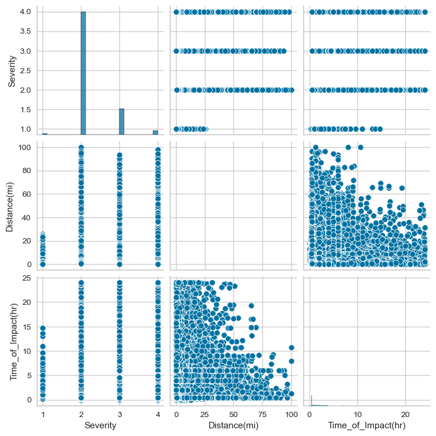

```python
sns.pairplot(data[['Severity','Distance(mi)','Time_of_Impact(hr)']]);
```

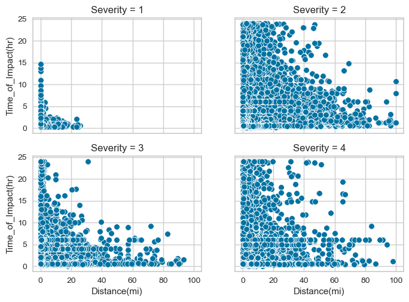

```python
fig,axs = plt.subplots(ncols=2,nrows=2,sharex=True,sharey=True);
ax = sns.scatterplot(data[data['Severity']==1][['Distance(mi)','Time_of_Impact(hr)']], x='Distance(mi)',y='Time_of_Impact(hr)', ax=axs[0][0]);
ax.set_title('Severity = 1');
ax = sns.scatterplot(data[data['Severity']==2][['Distance(mi)','Time_of_Impact(hr)']], x='Distance(mi)',y='Time_of_Impact(hr)', ax=axs[0][1]);
ax.set_title('Severity = 2');
ax = sns.scatterplot(data[data['Severity']==3][['Distance(mi)','Time_of_Impact(hr)']], x='Distance(mi)',y='Time_of_Impact(hr)', ax=axs[1][0]);
ax.set_title('Severity = 3');
ax = sns.scatterplot(data[data['Severity']==4][['Distance(mi)','Time_of_Impact(hr)']], x='Distance(mi)',y='Time_of_Impact(hr)', ax=axs[1][1]);
ax.set_title('Severity = 4');
```

Severity of 1 seems to be limited in both distance and duration of accident's impact. However, the other classes do not seem constrained.

## Relationships between Continous Variables

```python
if _SPARK_:
    corr_data = data.select(_NUMERICS_+['Severity'])
    col_names = corr_data.columns
    features = corr_data.rdd.map(lambda row: row[0:])
    corrs = Statistics.corr(features, method="pearson")
else:
    corrs = data[_NUMERICS_].corr()
    print(corrs)
```

```
                    Distance(mi)  Time_of_Impact(hr)  Temperature(F)  Wind_Chill(F)  Humidity(%)  Pressure(in)  Visibility(mi)  Wind_Speed(mph)  Precipitation(in)
Distance(mi)               1.000               0.150          -0.056         -0.061        0.009        -0.096          -0.040            0.019              0.004
Time_of_Impact(hr)         0.150               1.000          -0.014         -0.013       -0.009        -0.007           0.005            0.007             -0.004
Temperature(F)            -0.056              -0.014           1.000          0.994       -0.332         0.109           0.217            0.043             -0.003
Wind_Chill(F)             -0.061              -0.013           0.994          1.000       -0.313         0.117           0.219           -0.007             -0.002
Humidity(%)                0.009              -0.009          -0.332         -0.313        1.000         0.116          -0.385           -0.182              0.082
Pressure(in)              -0.096              -0.007           0.109          0.117        0.116         1.000           0.038           -0.056              0.003
Visibility(mi)            -0.040               0.005           0.217          0.219       -0.385         0.038           1.000            0.020             -0.119
Wind_Speed(mph)            0.019               0.007           0.043         -0.007       -0.182        -0.056           0.020            1.000              0.021
Precipitation(in)          0.004              -0.004          -0.003         -0.002        0.082         0.003          -0.119            0.021              1.000
```

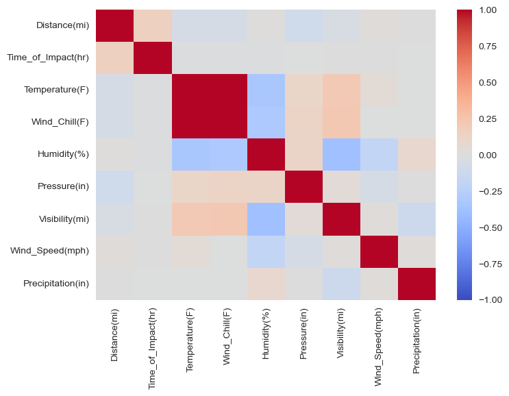

```python
sns.heatmap(corrs,vmin=-1,vmax=1,cmap='coolwarm');
```

Nothing particularly interesting here. Mostly intiutive relationships bear out.

## Dates

```python
first = pd.to_datetime(data['Start'].min())
last = pd.to_datetime(data['Start'].max())
print(f'Earliest date is {first}.')
print(f'Latest date is {last}.')
days = (last - first).days
print(f'A total of {days} days.')
```

```
Earliest date is 2016-01-14 20:18:33.
Latest date is 2023-03-31 23:30:00.
A total of 2633 days.
```

```python
days = ['Monday','Tuesday','Wednesday','Thursday','Friday','Saturday','Sunday']
months = [
            'January','February','March','April','May','June',
            'July','August','September','October','November','December'
         ]
counts = {}
counts['Total'] = (last - first).days
for i in range(0,len(days)):
    count = count_daytype(first,last,lambda d:(d.weekday() == i))
    counts[days[i]] = count
for i in range(1,5):
    counts['Q'+str(i)] = count_daytype(first,last,lambda d:(d.quarter == i))
for i in range(1,12):
    counts[months[i]] = count_daytype(first,last,lambda d:(d.month == i))
counts['Weekend'] = counts['Saturday'] + counts['Sunday']
counts['Weekday'] = counts['Total'] - counts['Weekend']
counts
```

```
{'Total': 2633,
 'Monday': 376,
 'Tuesday': 376,
 'Wednesday': 376,
 'Thursday': 377,
 'Friday': 377,
 'Saturday': 376,
 'Sunday': 376,
 'Q1': 709,
 'Q2': 637,
 'Q3': 644,
 'Q4': 644,
 'February': 235,
 'March': 226,
 'April': 248,
 'May': 210,
 'June': 217,
 'July': 210,
 'August': 217,
 'September': 217,
 'October': 210,
 'November': 217,
 'December': 210,
 'Weekend': 752,
 'Weekday': 1881}
```

```python
if _SPARK_:
    accdidents_year = data.stat.crosstab('Year','Severity')
else:
    accdidents_year = pd.crosstab(data['Year'],data['Severity'])

    accdidents_year['Total']=accdidents_year.sum(axis=1)
    accdidents_year['Average']=accdidents_year.apply(lambda r:sum(i*r[i] for i in range(1,5))/r['Total'],axis=1)
    accidents_calendar = pd.pivot_table(data,columns='Year',index='Month',values='Severity')
    accidents_calendar = pd.pivot_table(data,columns='Year',index='Quarter',values='Severity')
```

```python
display(accdidents_year)
print('*'*75)
print('Average Severity by Month in Dataset:')
display(accidents_calendar)
```

| Severity Year | 1 | 2 | 3 | 4 | Total | Average |
| --- | --- | --- | --- | --- | --- | --- |
| 2016 | 219 | 262186 | 121941 | 13675 | 398021 | 2.375 |
| 2017 | 270 | 448819 | 222774 | 23138 | 695001 | 2.387 |
| 2018 | 252 | 558998 | 281929 | 24564 | 865743 | 2.382 |
| 2019 | 198 | 670452 | 231764 | 27073 | 929487 | 2.307 |
| 2020 | 27922 | 900039 | 180107 | 29843 | 1137911 | 2.186 |
| 2021 | 147 | 1338598 | 144717 | 28572 | 1512034 | 2.133 |
| 2022 | 36543 | 1536980 | 74467 | 39250 | 1687240 | 2.069 |
| 2023 | 0 | 229630 | 0 | 6522 | 236152 | 2.055 |

```
Average Severity by Month in Dataset:
```

| Year Quarter | 2016 | 2017 | 2018 | 2019 | 2020 | 2021 | 2022 | 2023 |
| --- | --- | --- | --- | --- | --- | --- | --- | --- |
| 1 | 2.449 | 2.376 | 2.395 | 2.362 | 2.226 | 2.128 | 2.107 | 2.055 |
| 2 | 2.389 | 2.407 | 2.396 | 2.349 | 2.229 | 2.158 | 2.057 | NaN |
| 3 | 2.372 | 2.384 | 2.383 | 2.298 | 2.262 | 2.134 | 2.058 | NaN |
| 4 | 2.368 | 2.385 | 2.357 | 2.242 | 2.114 | 2.121 | 2.053 | NaN |

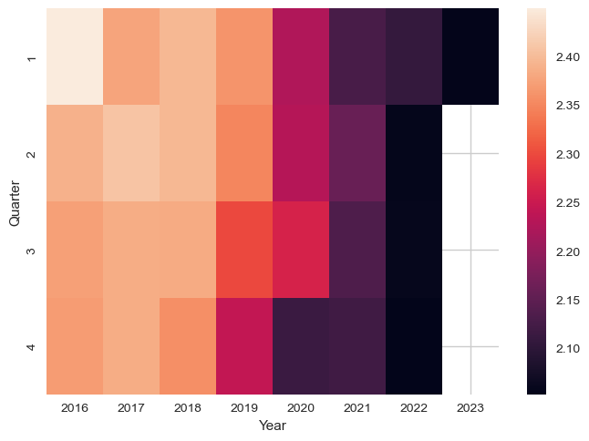

```python
sns.heatmap(accidents_calendar);
```

## Locations

```python
coords_count = data.value_counts(['Start_Lat','Start_Lng'])
coords_count
```

```
Start_Lat  Start_Lng
37.808     -122.367     569
33.941     -118.097     560
34.859     -82.260      542
42.477     -83.112      534
33.745     -84.390      528
                       ...
34.844     -80.932        1
           -87.653        1
           -80.932        1
           -82.431        1
49.002     -122.474       1
Name: count, Length: 2905569, dtype: int64
```

```python
if _LITE_SWITCH_:
    freq_coords = pd.DataFrame(index=coords_count[coords_count > 30].index)
else:
    freq_coords = pd.DataFrame(index=coords_count[coords_count > 250].index)
```

## Road Types

```python
data.groupby('State')['Federal'].sum().sort_values(ascending=False)
```

```
State
CA    463555
FL    175134
TX    144861
VA    103172
MN     93815
NC     74061
PA     73617
SC     72434
TN     64824
NY     61470
OR     53503
MI     51115
CO     47290
UT     46936
MO     44978
OH     42686
WA     41248
NJ     36757
IN     35043
IL     34849
AL     34177
LA     33078
GA     29479
CT     29465
MD     26678
AZ     23835
MA     21455
WI     19641
MT     16458
IA     14772
KS     13139
AR     12545
KY     10834
NV      9534
WV      9453
MS      8981
RI      8461
OK      7598
NE      5879
ID      4036
DC      3325
NH      3308
NM      3084
WY      2905
DE      1947
ND      1902
ME      1569
VT       370
SD        53
Name: Federal, dtype: int64
```

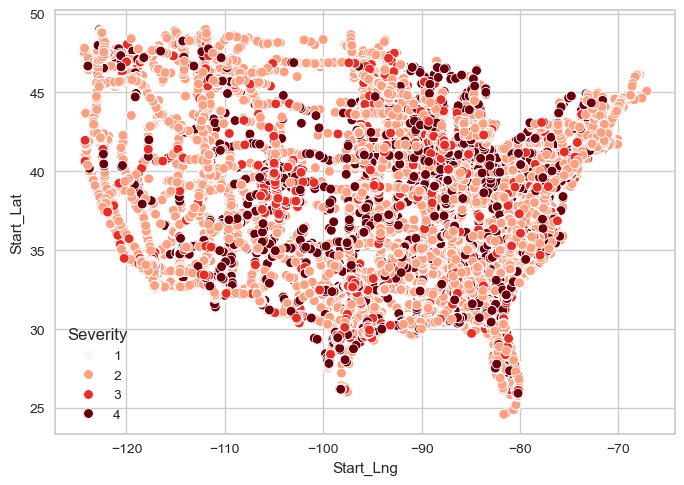

```python
sns.scatterplot(data[data['Federal']],
                x='Start_Lng',y='Start_Lat',
                hue='Severity',palette='Reds');
```

```python
federal_by_state = data[data.Federal].groupby('State')
federal_by_state = federal_by_state[['Severity','Distance(mi)','Time_of_Impact(hr)']]
federal_by_state = federal_by_state.mean()
federal_by_state
```

| State | Severity | Distance(mi) | Time_of_Impact(hr) |
| --- | --- | --- | --- |
| AL | 2.418 | 1.028 | 1.665 |
| AR | 2.177 | 2.028 | 1.729 |
| AZ | 2.293 | 1.515 | 1.977 |
| CA | 2.313 | 0.768 | 1.955 |
| CO | 2.550 | 1.195 | 1.697 |
| CT | 2.340 | 1.183 | 2.205 |
| DC | 2.214 | 0.669 | 2.268 |
| DE | 2.341 | 1.071 | 2.155 |
| FL | 2.364 | 1.248 | 2.004 |
| GA | 2.566 | 0.857 | 1.859 |
| IA | 2.407 | 2.195 | 1.790 |
| ID | 2.111 | 2.233 | 2.249 |
| IL | 2.714 | 0.885 | 1.942 |
| IN | 2.441 | 1.559 | 2.005 |
| KS | 2.268 | 0.836 | 1.737 |
| KY | 2.615 | 0.777 | 1.833 |
| LA | 2.393 | 1.291 | 1.847 |
| MA | 2.565 | 0.397 | 1.194 |
| MD | 2.361 | 0.990 | 1.823 |
| ME | 2.198 | 0.946 | 2.208 |
| MI | 2.443 | 0.829 | 1.783 |
| MN | 2.201 | 1.037 | 1.814 |
| MO | 2.451 | 0.666 | 1.913 |
| MS | 2.366 | 0.976 | 1.829 |
| MT | 2.043 | 3.209 | 1.965 |
| NC | 2.327 | 0.914 | 1.997 |
| ND | 2.015 | 2.522 | 1.659 |
| NE | 2.425 | 1.095 | 1.665 |
| NH | 2.363 | 0.727 | 2.549 |
| NJ | 2.311 | 0.656 | 2.075 |
| NM | 2.515 | 2.370 | 2.332 |
| NV | 2.260 | 1.232 | 2.179 |
| NY | 2.362 | 1.330 | 1.856 |
| OH | 2.531 | 0.941 | 1.898 |
| OK | 2.482 | 0.332 | 1.450 |
| OR | 2.118 | 1.674 | 3.267 |
| PA | 2.348 | 1.968 | 1.984 |
| RI | 2.523 | 0.380 | 1.645 |
| SC | 2.407 | 1.045 | 1.554 |
| SD | 2.736 | 4.632 | 4.536 |
| TN | 2.384 | 1.090 | 1.997 |
| TX | 2.500 | 0.643 | 1.977 |
| UT | 2.235 | 0.969 | 1.639 |
| VA | 2.331 | 1.408 | 1.871 |
| VT | 2.568 | 2.768 | 2.288 |
| WA | 2.522 | 0.775 | 2.483 |
| WI | 2.428 | 0.709 | 1.915 |
| WV | 2.154 | 1.452 | 3.906 |
| WY | 2.319 | 3.844 | 2.076 |

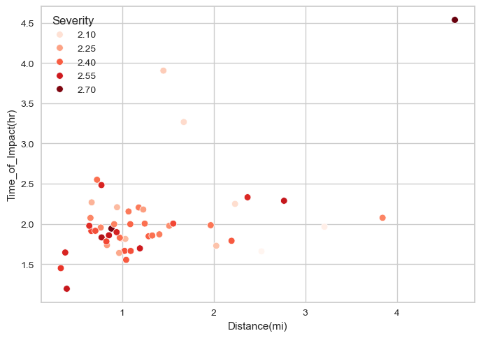

```python
sns.scatterplot(federal_by_state,x='Distance(mi)',y='Time_of_Impact(hr)',
                hue='Severity',palette='Reds');
```

## Infrastructure

https://highways.dot.gov/safety/speed-management/traffic-calming-eprimer/module-2-traffic-calming-basics

https://highways.dot.gov/safety/speed-management/traffic-calming-eprimer/module-3-part-1

```python
data[_INFRASTRUCTURE_].sum().sort_values(ascending=False)
```

```
Traffic_Signal     1115544
Crossing            854458
Junction            548978
Stop                207292
Station             196573
Amenity              93604
Railway              64510
Give_Way             35138
No_Exit              19107
Traffic_Calming       7351
Bump                  3422
Roundabout             244
Turning_Loop             0
dtype: int64
```

### Relation to Accident Nature

```python
differences = pd.DataFrame(index=infrastructures,columns=['Severity','Distance','Time_of_Impact'])
for infrastructure in infrastructures:
    if(data[infrastructure].sum() > 0):
        diff = data.groupby(infrastructure)[['Severity','Distance(mi)','Time_of_Impact(hr)']].mean().diff()
        differences.loc[infrastructure] = diff.loc[True].tolist()
    else:
        pass
differences
```

|  | Severity | Distance | Time_of_Impact |
| --- | --- | --- | --- |
| Amenity | -0.144 | -0.431 | -0.091 |
| Bump | -0.116 | -0.320 | -0.003 |
| Crossing | -0.167 | -0.497 | -0.196 |
| Give_Way | -0.039 | -0.249 | -0.264 |
| Junction | 0.095 | 0.210 | 0.374 |
| No_Exit | -0.100 | -0.334 | 0.046 |
| Railway | -0.060 | -0.329 | -0.108 |
| Roundabout | -0.142 | -0.440 | -0.208 |
| Station | -0.141 | -0.434 | 0.145 |
| Stop | -0.141 | -0.342 | -0.172 |
| Traffic_Calming | -0.086 | -0.349 | 0.025 |
| Traffic_Signal | -0.145 | -0.529 | -0.497 |
| Turning_Loop | NaN | NaN | NaN |

### Overlap

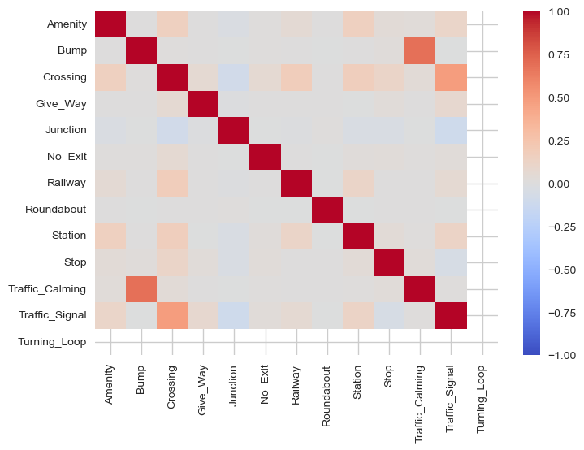

```python
sns.heatmap(data[infrastructures].corr(),vmin=-1,vmax=1,cmap='coolwarm');
```

```python
infra_counts = data[infrastructures].sum(axis=1)
infra_counts.sort_values(ascending=False)
```

```
ID
A-5016751    7
A-4541204    7
A-964556     6
A-5485979    6
A-3823371    6
            ..
A-3151632    0
A-3151631    0
A-3151630    0
A-3151628    0
A-7777761    0
Length: 7461589, dtype: int64
```

```python
calming_patterns = ['Traffic_Signal','Stop','Give_Way','Traffic_Calming','Bump','Roundabout']
```

```
0    6130513
1    1294574
2      35120
3       1351
4         31
Name: count, dtype: int64
```

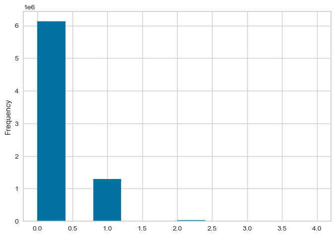

```python
calmings = data[calming_patterns].sum(axis=1)
display(calmings.value_counts())
calmings.plot.hist();
```

```python
data['Calming_Patterns'] = calmings
```

```python
print('Severity')
display(data.groupby('Calming_Patterns')['Severity'].describe())
print('-'*50)
print('Distance(mi)')
display(data.groupby('Calming_Patterns')['Distance(mi)'].describe())
print('-'*50)
print('Time_of_Impact(hr)')
data.groupby('Calming_Patterns')['Time_of_Impact(hr)'].describe()
```

```
Severity
```

| Calming_Patterns | count | mean | std | min | 25% | 50% | 75% | max |
| --- | --- | --- | --- | --- | --- | --- | --- | --- |
| 0 | 6130513.000 | 2.238 | 0.498 | 1.000 | 2.000 | 2.000 | 2.000 | 4.000 |
| 1 | 1294574.000 | 2.088 | 0.400 | 1.000 | 2.000 | 2.000 | 2.000 | 4.000 |
| 2 | 35120.000 | 2.113 | 0.428 | 1.000 | 2.000 | 2.000 | 2.000 | 4.000 |
| 3 | 1351.000 | 2.033 | 0.262 | 1.000 | 2.000 | 2.000 | 2.000 | 4.000 |
| 4 | 31.000 | 1.968 | 0.180 | 1.000 | 2.000 | 2.000 | 2.000 | 2.000 |

```
--------------------------------------------------
Distance(mi)
```

| Calming_Patterns | count | mean | std | min | 25% | 50% | 75% | max |
| --- | --- | --- | --- | --- | --- | --- | --- | --- |
| 0 | 6130513.000 | 0.646 | 1.814 | 0.000 | 0.000 | 0.074 | 0.597 | 99.952 |
| 1 | 1294574.000 | 0.125 | 0.679 | 0.000 | 0.000 | 0.000 | 0.020 | 71.624 |
| 2 | 35120.000 | 0.156 | 0.738 | 0.000 | 0.000 | 0.000 | 0.026 | 36.750 |
| 3 | 1351.000 | 0.122 | 0.344 | 0.000 | 0.000 | 0.010 | 0.114 | 3.700 |
| 4 | 31.000 | 0.118 | 0.237 | 0.000 | 0.000 | 0.000 | 0.065 | 1.000 |

```
--------------------------------------------------
Time_of_Impact(hr)
```

| Calming_Patterns | count | mean | std | min | 25% | 50% | 75% | max |
| --- | --- | --- | --- | --- | --- | --- | --- | --- |
| 0 | 6130513.000 | 1.891 | 2.163 | 0.000 | 0.567 | 1.258 | 2.131 | 24.000 |
| 1 | 1294574.000 | 1.428 | 1.724 | 0.000 | 0.497 | 0.991 | 1.500 | 24.000 |
| 2 | 35120.000 | 1.480 | 1.797 | 0.000 | 0.497 | 0.993 | 1.569 | 23.733 |
| 3 | 1351.000 | 1.810 | 2.315 | 0.250 | 0.499 | 1.252 | 2.080 | 16.565 |
| 4 | 31.000 | 1.249 | 1.204 | 0.494 | 0.536 | 1.013 | 1.304 | 7.000 |

### Clustering?

#### Basic K-Means

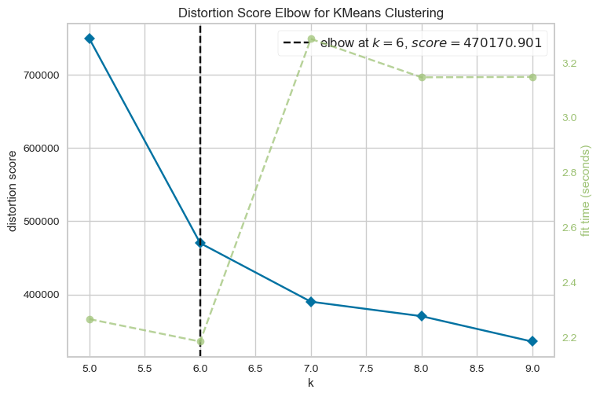

```python
X = data[_INFRASTRUCTURE_]
km = KMeans(random_state=42)
visualizer = KElbowVisualizer(km,k=(5,10))
visualizer.fit(X)
visualizer.show();
```

```python
km = KMeans(random_state=42,n_clusters=visualizer.elbow_value_)
km.fit(X)
```

```
KMeans(n_clusters=6, random_state=42)
```

```python
described_obsv = pd.DataFrame(data[_INFRASTRUCTURE_])
described_obsv['Cluster'] = km.labels_
described_obsv['Severity'] = data['Severity']
described_obsv['Distance(mi)'] = data['Distance(mi)']
described_obsv['Time_of_Impact(hr)'] = data['Time_of_Impact(hr)']
described_obsv
```

| ID | Stop | Traffic_Signal | Roundabout | Turning_Loop | Traffic_Calming | Bump | Amenity | Railway | Station | No_Exit | Crossing | Junction | Give_Way | Cluster | Severity | Distance(mi) | Time_of_Impact(hr) |
| --- | --- | --- | --- | --- | --- | --- | --- | --- | --- | --- | --- | --- | --- | --- | --- | --- | --- |
| A-1 | False | False | False | False | False | False | False | False | False | False | False | False | False | 0 | 3 | 0.010 | 5.233 |
| A-2 | False | False | False | False | False | False | False | False | False | False | False | False | False | 0 | 2 | 0.010 | 0.500 |
| A-3 | False | True | False | False | False | False | False | False | False | False | False | False | False | 1 | 2 | 0.010 | 0.500 |
| A-4 | False | False | False | False | False | False | False | False | False | False | False | False | False | 0 | 3 | 0.010 | 0.500 |
| A-5 | False | True | False | False | False | False | False | False | False | False | False | False | False | 1 | 2 | 0.010 | 0.500 |
| ... | ... | ... | ... | ... | ... | ... | ... | ... | ... | ... | ... | ... | ... | ... | ... | ... | ... |
| A-7777757 | False | False | False | False | False | False | False | False | False | False | False | False | False | 0 | 2 | 0.543 | 0.477 |
| A-7777758 | False | False | False | False | False | False | False | False | False | False | False | False | False | 0 | 2 | 0.338 | 0.448 |
| A-7777759 | False | False | False | False | False | False | False | False | False | False | False | True | False | 2 | 2 | 0.561 | 0.474 |
| A-7777760 | False | False | False | False | False | False | False | False | False | False | False | False | False | 0 | 2 | 0.772 | 0.489 |
| A-7777761 | False | False | False | False | False | False | False | False | False | False | False | False | False | 0 | 2 | 0.537 | 0.490 |

7461589 rows × 17 columns

```python
described_obsv.groupby('Cluster')[['Severity','Distance(mi)','Time_of_Impact(hr)']].mean()
```

| Cluster | Severity | Distance(mi) | Time_of_Impact(hr) |
| --- | --- | --- | --- |
| 0 | 2.240 | 0.658 | 1.856 |
| 1 | 2.111 | 0.115 | 1.361 |
| 2 | 2.298 | 0.754 | 2.158 |
| 3 | 2.072 | 0.221 | 1.640 |
| 4 | 2.066 | 0.155 | 2.058 |
| 5 | 2.064 | 0.089 | 1.413 |

| Cluster | 0 | 1 | 2 | 3 | 4 | 5 |
| --- | --- | --- | --- | --- | --- | --- |
| Stop | 0.000 | 0.006 | 0.005 | 1.000 | 0.000 | 0.012 |
| Traffic_Signal | 0.000 | 1.000 | 0.000 | 0.000 | 0.000 | 1.000 |
| Roundabout | 0.000 | 0.000 | 0.000 | 0.000 | 0.000 | 0.000 |
| Turning_Loop | 0.000 | 0.000 | 0.000 | 0.000 | 0.000 | 0.000 |
| Traffic_Calming | 0.001 | 0.000 | 0.000 | 0.005 | 0.004 | 0.003 |
| Bump | 0.000 | 0.000 | 0.000 | 0.003 | 0.002 | 0.000 |
| Amenity | 0.005 | 0.019 | 0.001 | 0.033 | 0.047 | 0.064 |
| Railway | 0.003 | 0.001 | 0.004 | 0.012 | 0.083 | 0.044 |
| Station | 0.014 | 0.046 | 0.004 | 0.059 | 0.095 | 0.104 |
| No_Exit | 0.001 | 0.002 | 0.002 | 0.010 | 0.010 | 0.011 |
| Crossing | 0.000 | 0.000 | 0.005 | 0.324 | 1.000 | 1.000 |
| Junction | 0.000 | 0.009 | 1.000 | 0.004 | 0.002 | 0.008 |
| Give_Way | 0.002 | 0.015 | 0.002 | 0.016 | 0.010 | 0.019 |

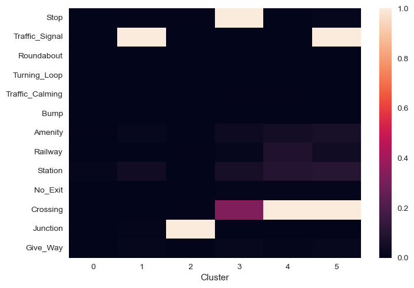

```python
avgs = described_obsv.groupby('Cluster')[_INFRASTRUCTURE_].mean().T
sns.heatmap(avgs)
display(avgs)
```

## Weather

```python
if _SPARK_:
    spark = SparkSession.builder.appName("Accident Data Project").getOrCreate()
    data = spark.read.csv('AccidentData_Clean.csv',header=True,inferSchema=True)
else:
    if _LITE_SWITCH_:
        data = pd.read_csv('AccidentData_Sampled_Clean.csv')
    else:
        data = pd.read_csv('AccidentData_Clean.csv')
```

### Weather-Wind Direction

```python
map_full = {
            'Calm':'0','CALM':'0',
            'SW':'SW','SSW':'SSW','SE':'SE','SSE':'SSE','S':'S',
            'WSW':'WSW','WNW':'WNW','W':'W',
            'NW':'NW','NNW': 'NNW','NNE':'NNE','NE':'NE','N':'N',
            'ESE':'ESE','ENE':'ENE','E':'E',
            'South':'S','North':'N','West':'W','East':'E',
            'Variable':'VAR','VAR':'VAR'
           }

map_second = {
            'Calm':'0','CALM':'0',
            'SW':'SW','SSW':'SW','SE':'SE','SSE':'SE','S':'S',
            'WSW':'SW','WNW':'NW','W':'W',
            'NW':'NW','NNW': 'NW','NNE':'NE','NE':'NE','N':'N',
            'ESE':'SE','ENE':'NE','E':'E',
            'South':'S','North':'N','West':'W','East':'E',
            'Variable':'VAR','VAR':'VAR'
          }

map_first = {
            'Calm':'0','CALM':'0',
            'SW':'SW','SSW':'S','SE':'SE','SSE':'S','S':'S',
            'WSW':'W','WNW':'W','W':'W',
            'NW':'NW','NNW': 'N','NNE':'N','NE':'NE','N':'N',
            'ESE':'E','ENE':'E','E':'E',
            'South':'S','North':'N','West':'W','East':'E',
            'Variable':'VAR','VAR':'VAR'
          }
```

```python
wind_directions = data['Wind_Direction'].value_counts(normalize=True,dropna=False)
wind_directions.sort_values(ascending=False)
```

```
Wind_Direction
CALM       0.131
S          0.055
SSW        0.051
W          0.051
WNW        0.050
NW         0.049
Calm       0.049
SW         0.048
WSW        0.047
SSE        0.046
NNW        0.044
N          0.040
SE         0.039
E          0.037
ESE        0.035
ENE        0.034
NE         0.034
NNE        0.034
VAR        0.033
South      0.024
West       0.022
North      0.018
Variable   0.015
East       0.014
Name: proportion, dtype: float64
```

```python
data['Wind_Direction'].map(map_full).value_counts(normalize=True,dropna=False).sort_values(ascending=False)
```

```
Wind_Direction
0     0.180
S     0.079
W     0.072
N     0.059
SSW   0.051
E     0.051
WNW   0.050
NW    0.049
SW    0.048
VAR   0.048
WSW   0.047
SSE   0.046
NNW   0.044
SE    0.039
ESE   0.035
ENE   0.034
NE    0.034
NNE   0.034
Name: proportion, dtype: float64
```

```python
data['Wind_Direction'].map(map_second).value_counts(normalize=True,dropna=False).sort_values(ascending=False)
```

```
Wind_Direction
0     0.180
SW    0.146
NW    0.143
SE    0.121
NE    0.102
S     0.079
W     0.072
N     0.059
E     0.051
VAR   0.048
Name: proportion, dtype: float64
```

```python
data['Wind_Direction'].map(map_first).value_counts(normalize=True,dropna=False).sort_values(ascending=False)
```

```
Wind_Direction
0     0.180
S     0.176
W     0.169
N     0.137
E     0.120
NW    0.049
SW    0.048
VAR   0.048
SE    0.039
NE    0.034
Name: proportion, dtype: float64
```

```python
data['Wind_Direction_Original'] = data['Wind_Direction']
data['Wind_Direction_Sub2'] = data['Wind_Direction_Original'].map(map_full)
data['Wind_Direction_Sub1'] = data['Wind_Direction_Original'].map(map_second)
data['Wind_Direction'] = data['Wind_Direction_Original'].map(map_first)
data = data.drop(['Wind_Direction_Original'],axis = 1)
data.shape[0]
```

```
7461589
```

### Extreme Weather

https://www.google.com/search?q=highest+wind+speeds+in+us&rlz=1C5OZZY_enUS1127US1127&oq=highest+wind+speeds+in+us&gs_lcrp=EgZjaHJvbWUyBggAEEUYOTIICAEQABgWGB4yCAgCEAAYFhgeMggIAxAAGBYYHjIICAQQABgWGB4yCAgFEAAYFhgeMggIBhAAGBYYHjIICAcQABgWGB4yCAgIEAAYFhgeMggICRAAGBYYHtIBCDYwNTdqMGo3qAIAsAIA&sourceid=chrome&ie=UTF-8

Wind speed greater than 230.

https://www.google.com/search?q=hottest+and+coldest+temperatures+wind+chill+united+states&sca_esv=5f3e024f075fa025&rlz=1C5OZZY_enUS1127US1127&ei=zR2JaNHUHomB5OMPht6bgAs&oq=hottest+and+coldest+temperatures+wind+chill+united&gs_lp=Egxnd3Mtd2l6LXNlcnAiMmhvdHRlc3QgYW5kIGNvbGRlc3QgdGVtcGVyYXR1…&sclient=gws-wiz-serp

Wind-Chill Temps 117 & -108.

```python
weather_numb = ['Temperature(F)','Wind_Chill(F)','Humidity(%)','Pressure(in)','Visibility(mi)','Wind_Speed(mph)','Precipitation(in)']
```

```python
data[weather_numb].describe().loc[['min','max']].T
```

|  | min | max |
| --- | --- | --- |
| Temperature(F) | -45.000 | 203.000 |
| Wind_Chill(F) | -63.000 | 203.000 |
| Humidity(%) | 1.000 | 100.000 |
| Pressure(in) | 0.000 | 58.630 |
| Visibility(mi) | 0.000 | 140.000 |
| Wind_Speed(mph) | 0.000 | 1087.000 |
| Precipitation(in) | 0.000 | 36.470 |

```python
data.shape[0]
```

```
7461589
```

```python
data = data[117 >= data['Temperature(F)'] ]
data = data[data['Wind_Chill(F)'] > -108]
data = data[230 > data['Wind_Speed(mph)']]
```

```python
data.shape[0]
```

```
7461492
```

```python
weather_numb = ['Temperature(F)','Wind_Chill(F)','Humidity(%)','Pressure(in)','Visibility(mi)','Wind_Speed(mph)','Precipitation(in)']
print(pd.DataFrame({c:{z:count_outliers(data[c],z) for z in [3,5,10,15,20]} for c in weather_numb }).T)
```

```
                      3      5     10    15   20
Temperature(F)         0      0     0     0    0
Wind_Chill(F)          0      0     0     0    0
Humidity(%)            0      0     0     0    0
Pressure(in)          86     83    27    27   27
Visibility(mi)     14300   9686  5455  3248  801
Wind_Speed(mph)    55353   3745   181   123   88
Precipitation(in)  35993  15007  3923  1425  696
```

```python
z_limit = 15
x_cond_1 = (zscore(data['Wind_Speed(mph)'],nan_policy='omit') > z_limit)
x_cond_2 = (zscore(data['Visibility(mi)'],nan_policy='omit') > z_limit)
x_cond_3 = (zscore(data['Precipitation(in)'],nan_policy='omit') > z_limit)
any_extreme = (x_cond_1 | x_cond_2 | x_cond_3)
all_extreme = (x_cond_1 & x_cond_2 & x_cond_3)
vis_wind_x = (x_cond_1 & x_cond_2)
vis_rain_x = (x_cond_3 & x_cond_2)
wind_rain_x = (x_cond_3 & x_cond_1)
extremes = [any_extreme,all_extreme,
            vis_rain_x,vis_wind_x,wind_rain_x,
            x_cond_1,x_cond_2,x_cond_3
            ]
cond_types = ['any','all',
              'visuals_precipitation','visuals_wind','wind_rain',
              'wind','visuals','rain'
              ]
extreme_conditions = dict(zip(cond_types,extremes))
print(vis_rain_x.sum())
print(vis_wind_x.sum())
print(wind_rain_x.sum())
print(any_extreme.sum())
print(all_extreme.sum())
```

```
0
3
0
4793
0
```

```python
df_x_desc = pd.DataFrame(columns=cond_types,index = data['Weather_Condition'].unique())
for x_con in cond_types:
    df_x_desc[x_con] = data[extreme_conditions[x_con]]['Weather_Condition'].value_counts()

df_x_desc = df_x_desc.fillna(0).astype(int)

df_x_desc = df_x_desc.loc[df_x_desc.apply(lambda r:r.sum() > 0,axis=1)]
df_x_desc
```

|  | any | all | visuals_precipitation | visuals_wind | wind_rain | wind | visuals | rain |
| --- | --- | --- | --- | --- | --- | --- | --- | --- |
| Light Rain | 67 | 0 | 0 | 0 | 0 | 0 | 2 | 65 |
| Overcast | 187 | 0 | 0 | 0 | 0 | 5 | 30 | 152 |
| Mostly Cloudy | 952 | 0 | 0 | 0 | 0 | 6 | 915 | 31 |
| Rain | 41 | 0 | 0 | 0 | 0 | 0 | 0 | 41 |
| Light Snow | 1 | 0 | 0 | 0 | 0 | 0 | 0 | 1 |
| Haze | 5 | 0 | 0 | 0 | 0 | 0 | 5 | 0 |
| Scattered Clouds | 574 | 0 | 0 | 3 | 0 | 6 | 565 | 6 |
| Partly Cloudy | 872 | 0 | 0 | 0 | 0 | 1 | 851 | 20 |
| Clear | 482 | 0 | 0 | 0 | 0 | 15 | 373 | 94 |
| Snow | 1 | 0 | 0 | 0 | 0 | 0 | 0 | 1 |
| Light Drizzle | 1 | 0 | 0 | 0 | 0 | 0 | 0 | 1 |
| Fog | 4 | 0 | 0 | 0 | 0 | 0 | 1 | 3 |
| Heavy Rain | 144 | 0 | 0 | 0 | 0 | 5 | 0 | 139 |
| Cloudy | 37 | 0 | 0 | 0 | 0 | 0 | 17 | 20 |
| Smoke | 7 | 0 | 0 | 0 | 0 | 0 | 7 | 0 |
| Patches of Fog | 4 | 0 | 0 | 0 | 0 | 0 | 4 | 0 |
| Light Freezing Fog | 2 | 0 | 0 | 0 | 0 | 0 | 0 | 2 |
| Light Thunderstorms and Rain | 43 | 0 | 0 | 0 | 0 | 0 | 0 | 43 |
| Thunderstorms and Rain | 35 | 0 | 0 | 0 | 0 | 0 | 0 | 35 |
| Fair | 419 | 0 | 0 | 0 | 0 | 0 | 413 | 6 |
| Fair / Windy | 71 | 0 | 0 | 0 | 0 | 50 | 21 | 0 |
| Light Rain / Windy | 8 | 0 | 0 | 0 | 0 | 8 | 0 | 0 |
| Showers in the Vicinity | 5 | 0 | 0 | 0 | 0 | 0 | 5 | 0 |
| Light Rain with Thunder | 109 | 0 | 0 | 0 | 0 | 0 | 0 | 109 |
| Mostly Cloudy / Windy | 20 | 0 | 0 | 0 | 0 | 7 | 13 | 0 |
| Partly Cloudy / Windy | 29 | 0 | 0 | 0 | 0 | 1 | 26 | 2 |
| Thunder in the Vicinity | 22 | 0 | 0 | 0 | 0 | 0 | 0 | 22 |
| T-Storm | 156 | 0 | 0 | 0 | 0 | 0 | 0 | 156 |
| Heavy Thunderstorms and Rain | 88 | 0 | 0 | 0 | 0 | 1 | 0 | 87 |
| Thunderstorm | 2 | 0 | 0 | 0 | 0 | 0 | 0 | 2 |
| Thunder | 12 | 0 | 0 | 0 | 0 | 0 | 0 | 12 |
| Heavy T-Storm | 335 | 0 | 0 | 0 | 0 | 0 | 0 | 335 |
| Heavy T-Storm / Windy | 16 | 0 | 0 | 0 | 0 | 0 | 0 | 16 |
| Blowing Snow | 1 | 0 | 0 | 0 | 0 | 0 | 0 | 1 |
| Cloudy / Windy | 11 | 0 | 0 | 0 | 0 | 11 | 0 | 0 |
| Rain / Windy | 5 | 0 | 0 | 0 | 0 | 0 | 0 | 5 |
| Heavy Rain / Windy | 1 | 0 | 0 | 0 | 0 | 0 | 0 | 1 |
| Thunder / Windy | 1 | 0 | 0 | 0 | 0 | 1 | 0 | 0 |
| T-Storm / Windy | 10 | 0 | 0 | 0 | 0 | 2 | 0 | 8 |
| Haze / Windy | 2 | 0 | 0 | 0 | 0 | 2 | 0 | 0 |
| Light Drizzle / Windy | 1 | 0 | 0 | 0 | 0 | 1 | 0 | 0 |
| Snow / Windy | 1 | 0 | 0 | 0 | 0 | 1 | 0 | 0 |
| Light Sleet | 7 | 0 | 0 | 0 | 0 | 0 | 0 | 7 |
| Heavy Thunderstorms with Small Hail | 2 | 0 | 0 | 0 | 0 | 0 | 0 | 2 |

```python
data = data.loc[~any_extreme].copy()
```

```python
data.shape
```

```
(7456699, 61)
```

### Weather Conditions

```python
weather_descriptions = data.Weather_Condition.unique()
print(f'There are {weather_descriptions.shape[0]} ways that the weather is described in this dataset: \n')
print(weather_descriptions)
```

```
There are 142 ways that the weather is described in this dataset:

['Light Rain' 'Overcast' 'Mostly Cloudy' 'Rain' 'Light Snow' 'Haze'
 'Scattered Clouds' 'Partly Cloudy' 'Clear' 'Snow'
 'Light Freezing Drizzle' 'Light Drizzle' 'Fog' 'Shallow Fog' 'Heavy Rain'
 'Light Freezing Rain' 'Cloudy' 'Drizzle' 'Light Rain Showers' 'Mist'
 'Smoke' 'Patches of Fog' 'Light Freezing Fog' 'Light Haze'
 'Light Thunderstorms and Rain' 'Thunderstorms and Rain' 'Fair'
 'Volcanic Ash' 'Blowing Sand' 'Blowing Dust / Windy' 'Widespread Dust'
 'Fair / Windy' 'Rain Showers' 'Light Rain / Windy' 'Hail' 'Heavy Drizzle'
 'Showers in the Vicinity' 'Light Rain Shower' 'Light Rain with Thunder'
 'Mostly Cloudy / Windy' 'Partly Cloudy / Windy' 'Thunder in the Vicinity'
 'T-Storm' 'Heavy Thunderstorms and Rain' 'Thunderstorm' 'Thunder'
 'Heavy T-Storm' 'Funnel Cloud' 'Heavy T-Storm / Windy' 'Blowing Snow'
 'Light Thunderstorms and Snow' 'Heavy Snow' 'Low Drifting Snow'
 'Light Ice Pellets' 'Ice Pellets' 'Squalls' 'N/A Precipitation'
 'Cloudy / Windy' 'Light Fog' 'Snow Grains' 'Snow Showers'
 'Heavy Thunderstorms and Snow' 'Rain / Windy' 'Heavy Rain / Windy'
 'Heavy Ice Pellets' 'Light Snow / Windy' 'Heavy Freezing Rain'
 'Small Hail' 'Heavy Rain Showers' 'Thunder / Windy' 'Drizzle and Fog'
 'T-Storm / Windy' 'Blowing Dust' 'Smoke / Windy' 'Haze / Windy' 'Tornado'
 'Light Drizzle / Windy' 'Widespread Dust / Windy' 'Wintry Mix'
 'Wintry Mix / Windy' 'Light Snow with Thunder' 'Fog / Windy'
 'Light Snow Shower' 'Sleet' 'Light Snow and Sleet' 'Rain Shower'
 'Snow and Sleet' 'Snow / Windy' 'Light Sleet' 'Heavy Snow / Windy'
 'Freezing Drizzle' 'Light Freezing Rain / Windy' 'Thunder / Wintry Mix'
 'Blowing Snow / Windy' 'Freezing Rain' 'Light Snow and Sleet / Windy'
 'Snow and Sleet / Windy' 'Sleet / Windy' 'Heavy Freezing Rain / Windy'
 'Squalls / Windy' 'Light Rain Shower / Windy' 'Snow and Thunder / Windy'
 'Light Sleet / Windy' 'Sand / Dust Whirlwinds' 'Drizzle / Windy'
 'Sand / Dust Whirls Nearby' 'Thunder and Hail' 'Heavy Sleet'
 'Freezing Rain / Windy' 'Partial Fog' 'Thunder / Wintry Mix / Windy'
 'Patches of Fog / Windy' 'Rain and Sleet' 'Light Snow Grains'
 'Partial Fog / Windy' 'Sand / Dust Whirlwinds / Windy' 'Snow and Thunder'
 'Heavy Snow with Thunder' 'Light Snow Showers' 'Heavy Blowing Snow'
 'Light Hail' 'Heavy Smoke' 'Heavy Thunderstorms with Small Hail'
 'Light Thunderstorm' 'Heavy Freezing Drizzle' 'Light Blowing Snow'
 'Thunderstorms and Snow' 'Dust Whirls' 'Mist / Windy'
 'Rain Shower / Windy' 'Sleet and Thunder' 'Heavy Sleet and Thunder'
 'Drifting Snow / Windy' 'Shallow Fog / Windy' 'Thunder and Hail / Windy'
 'Light Snow Shower / Windy' 'Heavy Sleet / Windy' 'Sand / Windy'
 'Heavy Rain Shower / Windy' 'Blowing Snow Nearby' 'Heavy Rain Shower'
 'Drifting Snow']
```

```python
description_counts = data.Weather_Condition.value_counts(dropna=False,normalize=True)
description_counts.sort_values(ascending=False)
```

```
Weather_Condition
Fair                        0.338
Mostly Cloudy               0.135
Cloudy                      0.108
Clear                       0.107
Partly Cloudy               0.093
                             ...
Blowing Snow Nearby         0.000
Partial Fog / Windy         0.000
Heavy Rain Shower / Windy   0.000
Sand / Windy                0.000
Drifting Snow               0.000
Name: proportion, Length: 142, dtype: float64
```

```python
description_counts.to_csv('condition_counts.csv')
```

To use this feature, we need to consolidate somehow.

### Exploration of Weather Condition Consolidation

Notice that there are a number of conditions that follow 'Condition/Windy' pattern. This may be worth exploring as a way to consolidate the data...especially, if we can conclude that the lack of 'Windy' in the description indicates the absence of wind.

```python
data['Wind_Condition'] = data.Weather_Condition.str.contains(r'([A-Za-z]+)( \/ Windy)')
```

| Wind_Condition | count | mean | std | min | 25% | 50% | 75% | max |
| --- | --- | --- | --- | --- | --- | --- | --- | --- |
| False | 7351296.000 | 7.027 | 5.037 | 0.000 | 3.000 | 6.900 | 10.000 | 85.200 |
| True | 105403.000 | 23.839 | 3.814 | 21.000 | 21.000 | 23.000 | 25.000 | 82.000 |

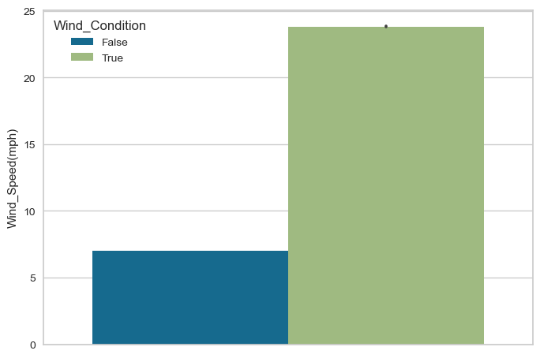

```python
sns.barplot(data=data,hue='Wind_Condition',y='Wind_Speed(mph)')
data.groupby('Wind_Condition')['Wind_Speed(mph)'].describe()
```

**[Per Google](https://www.google.com/search?client=safari&rls=en&q=highest+wind+speed+recorded+in+US&ie=UTF-8&oe=UTF-8)** the highest wind speed recorded in the US is 231 mph. So there might be some bad datapoints for observations regardless if they are described as windy.

Nevertheless, I think there is enough evidence that the extra description of 'windy' can be removed (and keeping the indicator).

```python
windy_split = data.Weather_Condition.str.split(r' \/ ')
data['Weather_Condition_New'] = windy_split.apply(lambda l:l[0])
```

```python
print(f'{data['Weather_Condition_New'].isna().sum()} missing values')
data['Weather_Condition_New'].value_counts(normalize=True).sort_values(ascending=False).head(25)
```

```
0 missing values
```

```
Weather_Condition_New
Fair                           0.343
Mostly Cloudy                  0.137
Cloudy                         0.110
Clear                          0.107
Partly Cloudy                  0.094
Overcast                       0.051
Light Rain                     0.048
Scattered Clouds               0.027
Light Snow                     0.018
Fog                            0.013
Rain                           0.011
Haze                           0.010
Heavy Rain                     0.004
Light Drizzle                  0.003
Thunder in the Vicinity        0.002
T-Storm                        0.002
Snow                           0.002
Thunder                        0.002
Light Rain with Thunder        0.002
Smoke                          0.002
Wintry Mix                     0.002
Heavy T-Storm                  0.001
Heavy Snow                     0.001
Light Thunderstorms and Rain   0.001
Drizzle                        0.001
Name: proportion, dtype: float64
```

```python
new_cardinal = len(data['Weather_Condition_New'].unique())
old_cardinal = len(data['Weather_Condition'].unique())
print(f'We have reduced the number of conditions from {old_cardinal} to {new_cardinal}.')
```

```
We have reduced the number of conditions from 142 to 95.
```

Some progress. But before manually choosing categories and mappings, let's consider using the continous features to create a consolidated but meaningful feature which maybe can improve on the categorical weather feature.

```python
weather_factors = ['Temperature(F)','Wind_Chill(F)','Humidity(%)',
                   'Pressure(in)','Visibility(mi)',
                   'Wind_Speed(mph)','Precipitation(in)',
                   'Wind_Direction'
                   ]
```

#### PCA

```python
X = data[weather_factors]
scaler = StandardScaler()
X = pd.get_dummies(X)
X_std =scaler.fit_transform(X)
```

```python
pca = PCA()
pca.fit(X_std);
```

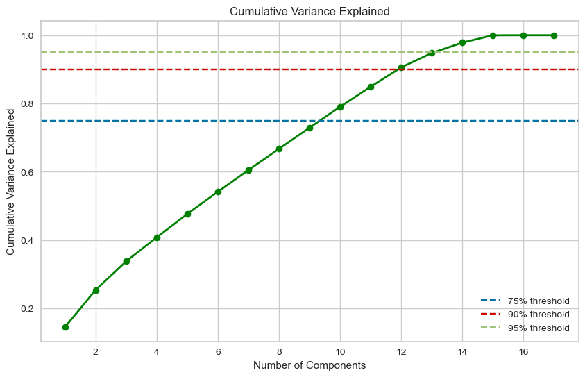

```python
cumulative_var = np.cumsum(pca.explained_variance_ratio_)
# Create a cumulative variance plot
plt.figure(figsize=(10, 6))
cum_var_plot = plt.plot(range(1, len(cumulative_var) + 1), cumulative_var,
         'o-', linewidth=2, color='green')
# Add lines for 75%, 90% and 95% thresholds
plt.axhline(y=0.75, color='b', linestyle='--', label='75% threshold')
plt.axhline(y=0.9, color='r', linestyle='--', label='90% threshold')
plt.axhline(y=0.95, color='g', linestyle='--', label='95% threshold')
plt.title('Cumulative Variance Explained')
plt.xlabel('Number of Components')
plt.ylabel('Cumulative Variance Explained')
plt.legend()
plt.grid(True)
plt.show()
```

```python
target_variance = 0.75
n_components_variance = np.argmax(cumulative_var >= target_variance) + 1
print(f'We choose to include the first {n_components_variance} components.')
```

```
We choose to include the first 10 components.
```

```python
pca = PCA(n_components=n_components_variance)
pca.fit(X_std);
# Transform the standardized data to get principal components
X_pca = pca.transform(X_std)
pcs = [f'PC{i+1}' for i in range(X_pca.shape[1])]
```

```python
# Create an easy to view DF of the loadings.
loadings = pd.DataFrame(
    pca.components_.T,
    columns=pcs,
    index=X.columns
)
loadings
```

|  | PC1 | PC2 | PC3 | PC4 | PC5 | PC6 | PC7 | PC8 | PC9 | PC10 |
| --- | --- | --- | --- | --- | --- | --- | --- | --- | --- | --- |
| Temperature(F) | 0.559 | -0.201 | 0.211 | -0.055 | -0.008 | -0.099 | 0.003 | 0.020 | 0.009 | 0.011 |
| Wind_Chill(F) | 0.550 | -0.236 | 0.210 | -0.052 | -0.009 | -0.099 | -0.001 | 0.023 | 0.011 | 0.011 |
| Humidity(%) | -0.391 | -0.104 | 0.373 | 0.017 | -0.082 | -0.001 | -0.058 | 0.072 | 0.084 | 0.002 |
| Pressure(in) | 0.053 | -0.140 | 0.180 | -0.196 | 0.127 | 0.057 | -0.259 | 0.019 | 0.440 | -0.115 |
| Visibility(mi) | 0.326 | -0.036 | -0.411 | 0.063 | 0.116 | 0.183 | -0.124 | 0.072 | 0.110 | 0.002 |
| Wind_Speed(mph) | 0.166 | 0.616 | 0.116 | -0.001 | -0.009 | 0.034 | 0.003 | 0.035 | 0.035 | 0.001 |
| Precipitation(in) | -0.100 | 0.051 | 0.465 | -0.116 | -0.130 | -0.289 | 0.184 | -0.126 | -0.143 | -0.003 |
| Wind_Direction_0 | -0.212 | -0.589 | -0.175 | 0.063 | -0.075 | 0.011 | -0.048 | 0.090 | -0.004 | 0.027 |
| Wind_Direction_E | 0.036 | 0.033 | 0.300 | -0.476 | -0.021 | 0.578 | -0.255 | -0.035 | -0.252 | 0.038 |
| Wind_Direction_N | -0.085 | 0.194 | -0.042 | -0.085 | 0.709 | -0.364 | -0.306 | 0.061 | -0.036 | 0.035 |
| Wind_Direction_NE | -0.023 | 0.035 | 0.100 | -0.074 | -0.015 | -0.069 | 0.187 | -0.072 | 0.630 | -0.527 |
| Wind_Direction_NW | -0.015 | 0.140 | -0.138 | 0.031 | 0.115 | 0.460 | 0.449 | -0.273 | 0.187 | 0.100 |
| Wind_Direction_S | 0.121 | 0.095 | 0.276 | 0.787 | -0.101 | 0.092 | -0.186 | -0.077 | -0.041 | -0.028 |
| Wind_Direction_SE | 0.030 | 0.014 | 0.102 | -0.062 | -0.009 | -0.137 | 0.289 | 0.214 | 0.338 | 0.759 |
| Wind_Direction_SW | 0.058 | 0.041 | 0.006 | -0.033 | 0.061 | 0.011 | 0.452 | 0.691 | -0.275 | -0.333 |
| Wind_Direction_VAR | 0.094 | -0.119 | -0.055 | -0.108 | 0.146 | -0.234 | 0.341 | -0.590 | -0.277 | -0.089 |
| Wind_Direction_W | 0.059 | 0.242 | -0.317 | -0.241 | -0.624 | -0.306 | -0.212 | -0.017 | 0.025 | -0.017 |

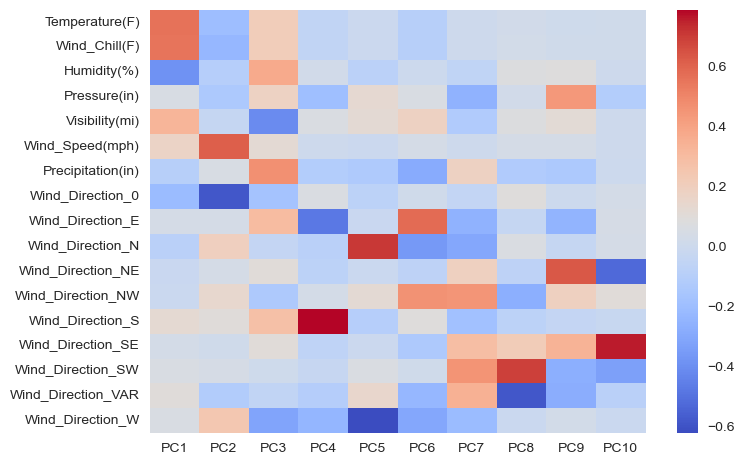

```python
sns.heatmap(loadings,cmap='coolwarm');
```

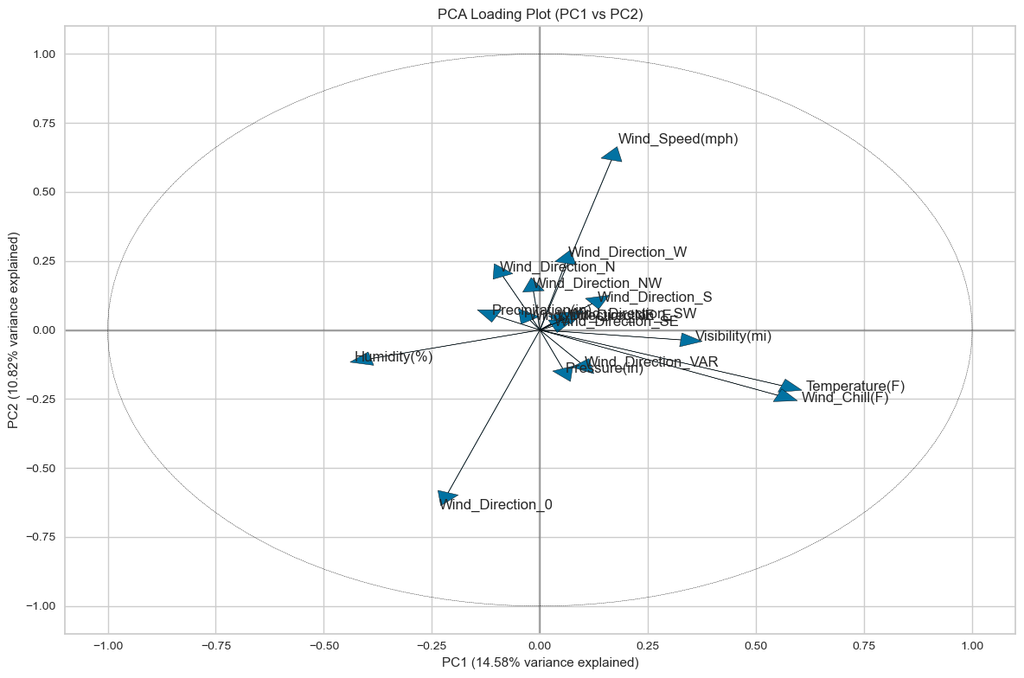

```python
# Visualize the loadings for the first two PCs
plt.figure(figsize=(12, 8))
for i, feature in enumerate(X.columns):
    plt.arrow(0, 0, loadings.iloc[i, 0], loadings.iloc[i, 1], head_width=0.05, head_length=0.05)
    plt.text(loadings.iloc[i, 0]*1.1, loadings.iloc[i, 1]*1.1, feature, fontsize=12)

# Add a unit circle for reference
circle = plt.Circle((0, 0), 1, fill=False, linestyle='--')
plt.gca().add_patch(circle)

plt.grid(True)
plt.axhline(y=0, color='k', linestyle='-', alpha=0.3)
plt.axvline(x=0, color='k', linestyle='-', alpha=0.3)
plt.xlim(-1.1, 1.1)
plt.ylim(-1.1, 1.1)
plt.title('PCA Loading Plot (PC1 vs PC2)')
plt.xlabel(f'PC1 ({pca.explained_variance_ratio_[0]:.2%} variance explained)')
plt.ylabel(f'PC2 ({pca.explained_variance_ratio_[1]:.2%} variance explained)')
plt.tight_layout()
plt.show()
```

All pretty expected:

- Temp & Wind Chill are obviously closely related.
- Wind_Direction_0 is the exact opposite of there being any wind speed.
- Other Wind directions are of limtied interest.

```python
# Create a DataFrame with the principal components
pca_df = pd.DataFrame(
    data=X_pca,
    columns=pcs
)
pca_df['Condition_1'] = data['Weather_Condition'].values
pca_df['Condition_2'] = data['Weather_Condition_New'].values
avg_pca_1 = pca_df.groupby('Condition_1')[pcs].mean()
avg_pca_2 = pca_df.groupby('Condition_2')[pcs].mean()
print(avg_pca_1)
print('--'*50)
print(avg_pca_2)
```

```
                           PC1    PC2    PC3    PC4    PC5    PC6    PC7    PC8    PC9   PC10
Condition_1
Blowing Dust             0.927  1.355 -0.315 -0.328  0.171 -0.602  0.210 -0.096 -0.277 -0.236
Blowing Dust / Windy     1.266  3.388 -0.260  0.037 -0.160 -0.633  0.699  0.184 -0.721 -0.018
Blowing Sand             1.389  0.284  0.363 -0.749 -0.981 -1.170  0.711 -0.441  1.290 -1.417
Blowing Snow            -3.669  3.164 -0.856 -0.133 -0.689 -0.026  0.203 -0.109 -0.165 -0.138
Blowing Snow / Windy    -4.131  4.369 -0.872 -0.022 -0.975  0.328  0.665 -0.401 -0.296  0.044
...                        ...    ...    ...    ...    ...    ...    ...    ...    ...    ...
Volcanic Ash             1.029 -0.650 -0.335 -0.429  2.268 -1.141 -0.988  0.164  0.068  0.067
Widespread Dust          1.364  2.186  0.100 -0.252 -0.578 -0.379  0.179  0.072  0.086 -0.301
Widespread Dust / Windy  1.322  3.119 -0.129 -0.201 -0.564 -0.178  1.517  1.008 -1.956 -0.223
Wintry Mix              -3.029  1.128  0.751 -0.179  0.194 -0.248  0.179 -0.228 -0.200 -0.143
Wintry Mix / Windy      -2.745  3.091  1.383 -0.607  0.253 -0.159  0.144 -0.225 -0.047 -0.294

[142 rows x 10 columns]
----------------------------------------------------------------------------------------------------
                          PC1    PC2    PC3    PC4    PC5    PC6    PC7    PC8    PC9   PC10
Condition_2
Blowing Dust            1.126  2.547 -0.283 -0.114 -0.023 -0.620  0.496  0.068 -0.537 -0.108
Blowing Sand            1.389  0.284  0.363 -0.749 -0.981 -1.170  0.711 -0.441  1.290 -1.417
Blowing Snow           -3.926  3.835 -0.865 -0.071 -0.848  0.171  0.460 -0.272 -0.238 -0.036
Blowing Snow Nearby    -1.412  2.213 -1.191  0.697 -0.442 -0.454  2.584  1.008 -0.064  4.366
Clear                   0.292 -0.272 -0.317 -0.068  0.135  0.036 -0.155 -0.009  0.228 -0.079
...                       ...    ...    ...    ...    ...    ...    ...    ...    ...    ...
Thunderstorms and Snow -4.023  2.368  4.528 -1.557 -1.759 -1.222  1.861 -1.526 -1.064  0.085
Tornado                 0.936  0.620  1.294 -0.509 -0.533 -0.950  1.328  1.057 -0.409 -0.006
Volcanic Ash            1.029 -0.650 -0.335 -0.429  2.268 -1.141 -0.988  0.164  0.068  0.067
Widespread Dust         1.359  2.296  0.073 -0.246 -0.576 -0.355  0.336  0.182 -0.154 -0.292
Wintry Mix             -3.021  1.182  0.768 -0.191  0.195 -0.246  0.178 -0.228 -0.196 -0.147

[95 rows x 10 columns]
```

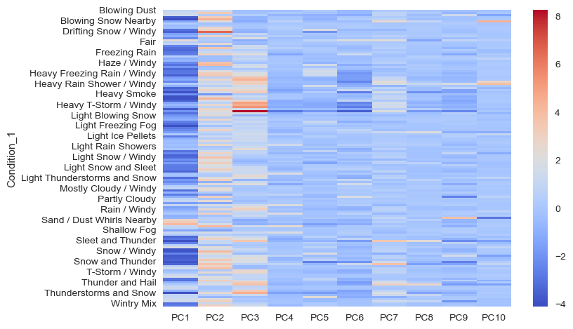

```python
sns.heatmap(avg_pca_1,cmap='coolwarm');
```

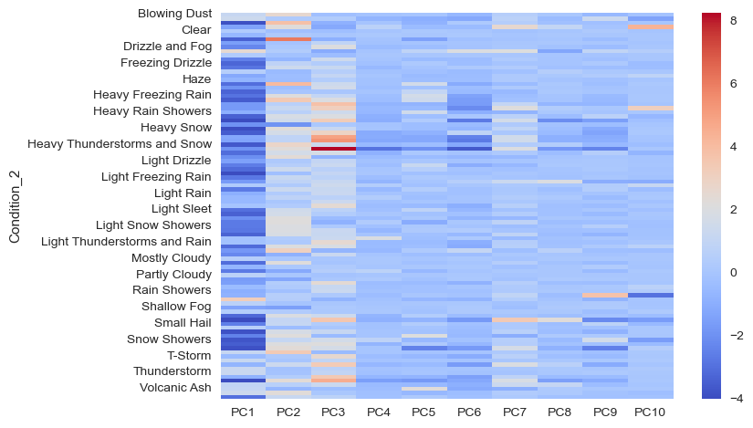

```python
sns.heatmap(avg_pca_2,cmap='coolwarm');
```

```python
try:
    del loadings,pca_df,avg_pca_1,avg_pca_2
except:
    pass
```

#### K-Means Clustering

```python
X = data[weather_factors+['Weather_Condition','Weather_Condition_New']]
```

```python
X.isna().sum()
```

```
Temperature(F)           0
Wind_Chill(F)            0
Humidity(%)              0
Pressure(in)             0
Visibility(mi)           0
Wind_Speed(mph)          0
Precipitation(in)        0
Wind_Direction           0
Weather_Condition        0
Weather_Condition_New    0
dtype: int64
```

```python
X = data[weather_factors+['Weather_Condition','Weather_Condition_New']][weather_factors]
scaler = StandardScaler()
X = pd.get_dummies(X)
X_std =scaler.fit_transform(X)
```

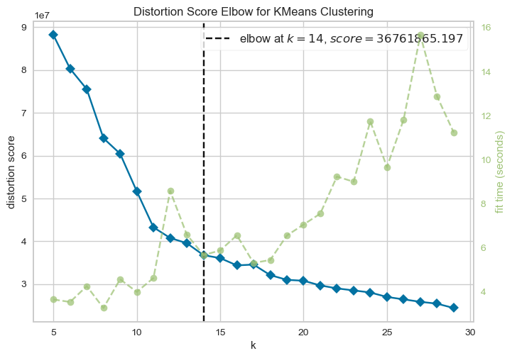

```python
km = KMeans(random_state=42)
visualizer = KElbowVisualizer(km,k=(5,30))
visualizer.fit(X_std)
visualizer.show();
```

Recall, the heavily-skewed distribution of weather descripitions. It makes sense that we would end up with limited clusters.

```python
km = KMeans(random_state=42,n_clusters=visualizer.elbow_value_)
km.fit(X_std)
```

```
KMeans(n_clusters=14, random_state=42)
```

```python
centroids = pd.DataFrame(scaler.inverse_transform(km.cluster_centers_),columns=X.columns)
centroids
```

|  | Temperature(F) | Wind_Chill(F) | Humidity(%) | Pressure(in) | Visibility(mi) | Wind_Speed(mph) | Precipitation(in) | Wind_Direction_0 | Wind_Direction_E | Wind_Direction_N | Wind_Direction_NE | Wind_Direction_NW | Wind_Direction_S | Wind_Direction_SE | Wind_Direction_SW | Wind_Direction_VAR | Wind_Direction_W |
| --- | --- | --- | --- | --- | --- | --- | --- | --- | --- | --- | --- | --- | --- | --- | --- | --- | --- |
| 0 | 56.854 | 54.660 | 64.333 | 29.747 | 8.907 | 8.897 | 0.004 | 0.000 | -0.000 | 1.000 | -0.000 | 0.000 | 0.000 | 0.000 | 0.000 | -0.000 | 0.000 |
| 1 | 72.808 | 72.804 | 52.741 | 29.612 | 9.739 | 9.290 | 0.001 | 0.000 | -0.000 | 0.000 | -0.000 | -0.000 | 0.000 | 0.000 | 0.000 | -0.000 | 1.000 |
| 2 | 58.042 | 58.042 | 72.725 | 29.711 | 8.804 | 0.000 | 0.002 | 1.000 | -0.000 | -0.000 | -0.000 | -0.000 | 0.000 | 0.000 | 0.000 | 0.000 | 0.000 |
| 3 | 46.496 | 43.303 | 55.833 | 24.920 | 8.793 | 7.838 | 0.003 | 0.202 | 0.110 | 0.200 | 0.007 | 0.018 | 0.235 | 0.009 | 0.028 | 0.019 | 0.171 |
| 4 | 46.357 | 43.454 | 81.645 | 29.661 | 7.040 | 7.586 | 0.013 | 0.000 | 1.000 | -0.000 | 0.000 | -0.000 | 0.000 | -0.000 | 0.000 | -0.000 | -0.000 |
| 5 | 67.246 | 66.522 | 65.701 | 29.647 | 9.305 | 9.136 | 0.003 | 0.000 | -0.000 | -0.000 | -0.000 | 0.000 | 1.000 | 0.000 | 0.000 | 0.000 | 0.000 |
| 6 | 65.875 | 64.978 | 67.793 | 29.559 | 9.080 | 8.510 | 0.004 | 0.000 | -0.000 | -0.000 | 0.000 | 0.000 | -0.000 | 1.000 | 0.000 | -0.000 | -0.000 |
| 7 | 66.091 | 65.077 | 61.968 | 29.545 | 9.406 | 8.992 | 0.002 | -0.000 | -0.000 | 0.000 | 0.000 | -0.000 | -0.000 | -0.000 | 1.000 | -0.000 | -0.000 |
| 8 | 64.780 | 64.255 | 91.852 | 29.581 | 3.886 | 9.152 | 0.372 | 0.089 | 0.193 | 0.177 | 0.044 | 0.035 | 0.205 | 0.043 | 0.040 | 0.042 | 0.131 |
| 9 | 60.439 | 58.950 | 68.586 | 29.713 | 8.695 | 8.379 | 0.006 | 0.000 | -0.000 | -0.000 | 1.000 | 0.000 | -0.000 | -0.000 | 0.000 | -0.000 | -0.000 |
| 10 | 69.783 | 69.457 | 54.853 | 29.628 | 9.444 | 4.775 | 0.002 | -0.000 | -0.000 | 0.000 | 0.000 | -0.000 | -0.000 | -0.000 | 0.000 | 1.000 | -0.000 |
| 11 | 37.060 | 31.064 | 70.329 | 29.554 | 8.694 | 10.280 | 0.003 | 0.000 | -0.000 | 0.000 | 0.000 | -0.000 | 0.020 | -0.000 | -0.000 | -0.000 | 0.980 |
| 12 | 74.864 | 74.849 | 60.633 | 29.808 | 9.917 | 8.919 | 0.001 | -0.000 | 1.000 | 0.000 | -0.000 | -0.000 | -0.000 | 0.000 | -0.000 | -0.000 | 0.000 |
| 13 | 56.580 | 53.900 | 57.847 | 29.569 | 9.307 | 10.025 | 0.002 | -0.000 | -0.000 | 0.000 | 0.000 | 1.000 | -0.000 | -0.000 | -0.000 | -0.000 | -0.000 |

```python
cluster_size = pd.Series(km.labels_).value_counts(normalize=True)
cluster_size.sort_values(ascending=False)
```

```
2    0.174
5    0.168
0    0.130
1    0.110
12   0.076
11   0.055
13   0.048
10   0.047
7    0.047
4    0.040
6    0.039
9    0.034
3    0.026
8    0.006
Name: proportion, dtype: float64
```

```python
described_obsv = pd.DataFrame(data[weather_factors+['Weather_Condition','Weather_Condition_New']])
described_obsv['Cluster'] = km.labels_
described_obsv['Severity'] = data['Severity']
described_obsv['Distance(mi)'] = data['Distance(mi)']
described_obsv['Time_of_Impact(hr)'] = data['Time_of_Impact(hr)']
described_obsv
```

|  | Temperature(F) | Wind_Chill(F) | Humidity(%) | Pressure(in) | Visibility(mi) | Wind_Speed(mph) | Precipitation(in) | Wind_Direction | Weather_Condition | Weather_Condition_New | Cluster | Severity | Distance(mi) | Time_of_Impact(hr) |
| --- | --- | --- | --- | --- | --- | --- | --- | --- | --- | --- | --- | --- | --- | --- |
| 0 | 36.900 | 36.900 | 91.000 | 29.680 | 10.000 | 0.000 | 0.020 | 0 | Light Rain | Light Rain | 2 | 3 | 0.010 | 5.233 |
| 1 | 37.900 | 37.900 | 100.000 | 29.650 | 10.000 | 0.000 | 0.000 | 0 | Light Rain | Light Rain | 2 | 2 | 0.010 | 0.500 |
| 2 | 36.000 | 33.300 | 100.000 | 29.670 | 10.000 | 3.500 | 0.000 | SW | Overcast | Overcast | 7 | 2 | 0.010 | 0.500 |
| 3 | 35.100 | 31.000 | 96.000 | 29.640 | 9.000 | 4.600 | 0.000 | SW | Mostly Cloudy | Mostly Cloudy | 7 | 3 | 0.010 | 0.500 |
| 4 | 36.000 | 33.300 | 89.000 | 29.650 | 6.000 | 3.500 | 0.000 | SW | Mostly Cloudy | Mostly Cloudy | 7 | 2 | 0.010 | 0.500 |
| ... | ... | ... | ... | ... | ... | ... | ... | ... | ... | ... | ... | ... | ... | ... |
| 7461584 | 86.000 | 86.000 | 40.000 | 28.920 | 10.000 | 13.000 | 0.000 | W | Fair | Fair | 1 | 2 | 0.543 | 0.477 |
| 7461585 | 70.000 | 70.000 | 73.000 | 29.390 | 10.000 | 6.000 | 0.000 | SW | Fair | Fair | 7 | 2 | 0.338 | 0.448 |
| 7461586 | 73.000 | 73.000 | 64.000 | 29.740 | 10.000 | 10.000 | 0.000 | S | Partly Cloudy | Partly Cloudy | 5 | 2 | 0.561 | 0.474 |
| 7461587 | 71.000 | 71.000 | 81.000 | 29.620 | 10.000 | 8.000 | 0.000 | SW | Fair | Fair | 7 | 2 | 0.772 | 0.489 |
| 7461588 | 79.000 | 79.000 | 47.000 | 28.630 | 7.000 | 7.000 | 0.000 | SW | Fair | Fair | 7 | 2 | 0.537 | 0.490 |

7456699 rows × 14 columns

##### Vs. Nature of Accident Variables

```python
cluster_v_accidents = pd.crosstab(described_obsv['Cluster'],described_obsv['Severity'],normalize='index')
cluster_v_accidents['Total Accidents'] = pd.Series(km.labels_).value_counts()
```

```python
cluster_v_accidents
```

| Severity Cluster | 1 | 2 | 3 | 4 | Total Accidents |
| --- | --- | --- | --- | --- | --- |
| 0 | 0.007 | 0.799 | 0.168 | 0.025 | 971496 |
| 1 | 0.013 | 0.787 | 0.179 | 0.021 | 821227 |
| 2 | 0.008 | 0.811 | 0.152 | 0.028 | 1296527 |
| 3 | 0.010 | 0.822 | 0.128 | 0.040 | 193219 |
| 4 | 0.004 | 0.791 | 0.176 | 0.028 | 297461 |
| 5 | 0.010 | 0.785 | 0.180 | 0.026 | 1249646 |
| 6 | 0.008 | 0.797 | 0.173 | 0.022 | 287222 |
| 7 | 0.012 | 0.784 | 0.176 | 0.027 | 352385 |
| 8 | 0.008 | 0.723 | 0.248 | 0.021 | 44898 |
| 9 | 0.008 | 0.801 | 0.167 | 0.024 | 251062 |
| 10 | 0.009 | 0.808 | 0.164 | 0.020 | 353283 |
| 11 | 0.003 | 0.788 | 0.173 | 0.036 | 410145 |
| 12 | 0.010 | 0.808 | 0.161 | 0.021 | 569115 |
| 13 | 0.008 | 0.799 | 0.168 | 0.025 | 359013 |

```python
cluster_avgs = described_obsv.groupby('Cluster')[['Severity','Time_of_Impact(hr)','Distance(mi)']].mean()
```

```python
cluster_v_accidents = cluster_v_accidents.join(cluster_avgs)
cluster_v_accidents
```

| Cluster | 1 | 2 | 3 | 4 | Total Accidents | Severity | Time_of_Impact(hr) | Distance(mi) |
| --- | --- | --- | --- | --- | --- | --- | --- | --- |
| 0 | 0.007 | 0.799 | 0.168 | 0.025 | 971496 | 2.212 | 1.796 | 0.543 |
| 1 | 0.013 | 0.787 | 0.179 | 0.021 | 821227 | 2.208 | 1.810 | 0.530 |
| 2 | 0.008 | 0.811 | 0.152 | 0.028 | 1296527 | 2.201 | 1.841 | 0.529 |
| 3 | 0.010 | 0.822 | 0.128 | 0.040 | 193219 | 2.198 | 1.893 | 1.247 |
| 4 | 0.004 | 0.791 | 0.176 | 0.028 | 297461 | 2.229 | 1.788 | 0.603 |
| 5 | 0.010 | 0.785 | 0.180 | 0.026 | 1249646 | 2.222 | 1.770 | 0.499 |
| 6 | 0.008 | 0.797 | 0.173 | 0.022 | 287222 | 2.209 | 1.822 | 0.508 |
| 7 | 0.012 | 0.784 | 0.176 | 0.027 | 352385 | 2.219 | 1.759 | 0.541 |
| 8 | 0.008 | 0.723 | 0.248 | 0.021 | 44898 | 2.282 | 1.635 | 0.619 |
| 9 | 0.008 | 0.801 | 0.167 | 0.024 | 251062 | 2.208 | 1.798 | 0.530 |
| 10 | 0.009 | 0.808 | 0.164 | 0.020 | 353283 | 2.194 | 1.793 | 0.520 |
| 11 | 0.003 | 0.788 | 0.173 | 0.036 | 410145 | 2.242 | 1.776 | 0.658 |
| 12 | 0.010 | 0.808 | 0.161 | 0.021 | 569115 | 2.193 | 1.885 | 0.474 |
| 13 | 0.008 | 0.799 | 0.168 | 0.025 | 359013 | 2.211 | 1.830 | 0.589 |

##### Vs. Description of Weather (2x)

Original Categories

```python
cluster_v_descr = pd.crosstab(described_obsv['Cluster'],described_obsv['Weather_Condition'])
cluster_v_descr['Total'] = cluster_v_descr.sum(axis=1)
cluster_v_descr.loc['Total'] = cluster_v_descr.sum(axis=0)
cluster_v_descr
```

| Weather_Condition Cluster | Blowing Dust | Blowing Dust / Windy | Blowing Sand | Blowing Snow | Blowing Snow / Windy | Blowing Snow Nearby | Clear | Cloudy | Cloudy / Windy | Drifting Snow | Drifting Snow / Windy | Drizzle | Drizzle / Windy | Drizzle and Fog | Dust Whirls | Fair | Fair / Windy | Fog | Fog / Windy | Freezing Drizzle | Freezing Rain | Freezing Rain / Windy | Funnel Cloud | Hail | Haze | Haze / Windy | Heavy Blowing Snow | Heavy Drizzle | Heavy Freezing Drizzle | … |
| --- | --- | --- | --- | --- | --- | --- | --- | --- | --- | --- | --- | --- | --- | --- | --- | --- | --- | --- | --- | --- | --- | --- | --- | --- | --- | --- | --- | --- | --- | --- |
| 0 | 59 | 59 | 0 | 123 | 37 | 0 | 108952 | 125001 | 2685 | 1 | 0 | 887 | 3 | 62 | 0 | 303672 | 5908 | 9623 | 275 | 11 | 40 | 1 | 3 | 1 | 6169 | 173 | 4 | 87 | 3 | … |
| 1 | 57 | 28 | 1 | 0 | 0 | 0 | 109084 | 49048 | 653 | 0 | 0 | 83 | 0 | 0 | 0 | 339942 | 7002 | 611 | 1 | 0 | 0 | 0 | 4 | 0 | 11012 | 68 | 0 | 4 | 0 | … |
| 2 | 0 | 0 | 0 | 12 | 0 | 0 | 179386 | 124221 | 0 | 0 | 0 | 1106 | 0 | 53 | 0 | 556301 | 0 | 42936 | 0 | 7 | 8 | 0 | 5 | 12 | 23325 | 0 | 0 | 124 | 2 | … |
| 3 | 12 | 84 | 0 | 19 | 43 | 0 | 24 | 24861 | 1346 | 0 | 0 | 45 | 3 | 9 | 0 | 79123 | 3144 | 2449 | 103 | 1 | 0 | 0 | 0 | 0 | 1383 | 121 | 0 | 2 | 0 | … |
| 4 | 2 | 0 | 0 | 6 | 10 | 0 | 15789 | 50587 | 542 | 0 | 0 | 779 | 0 | 148 | 0 | 50768 | 371 | 11018 | 18 | 2 | 70 | 17 | 0 | 3 | 4612 | 21 | 0 | 83 | 0 | … |
| 5 | 9 | 9 | 0 | 2 | 0 | 0 | 124304 | 142541 | 3849 | 0 | 0 | 539 | 2 | 52 | 0 | 366787 | 5528 | 10597 | 125 | 0 | 15 | 0 | 3 | 3 | 8531 | 103 | 0 | 40 | 0 | … |
| 6 | 0 | 10 | 0 | 0 | 1 | 1 | 23228 | 34343 | 640 | 0 | 0 | 174 | 2 | 18 | 0 | 82312 | 408 | 3648 | 4 | 0 | 5 | 0 | 1 | 8 | 2260 | 10 | 0 | 25 | 0 | … |
| 7 | 9 | 22 | 0 | 48 | 32 | 0 | 37751 | 34871 | 848 | 0 | 0 | 156 | 0 | 1 | 0 | 114334 | 2184 | 2195 | 6 | 0 | 12 | 0 | 2 | 0 | 3110 | 49 | 0 | 21 | 0 | … |
| 8 | 0 | 0 | 0 | 0 | 0 | 0 | 33 | 1077 | 32 | 0 | 0 | 4 | 0 | 0 | 0 | 225 | 17 | 141 | 11 | 0 | 0 | 0 | 0 | 4 | 35 | 0 | 0 | 2 | 0 | … |
| 9 | 19 | 26 | 1 | 11 | 3 | 0 | 21575 | 35467 | 378 | 0 | 0 | 357 | 4 | 29 | 0 | 66912 | 580 | 3297 | 17 | 5 | 30 | 0 | 0 | 0 | 1471 | 11 | 0 | 25 | 0 | … |
| 10 | 0 | 0 | 0 | 0 | 0 | 0 | 47780 | 28484 | 0 | 0 | 0 | 9 | 0 | 3 | 0 | 136904 | 0 | 2273 | 0 | 0 | 7 | 0 | 0 | 0 | 4655 | 0 | 0 | 0 | 0 | … |
| 11 | 0 | 7 | 0 | 418 | 563 | 0 | 38979 | 64589 | 3501 | 0 | 6 | 284 | 4 | 15 | 0 | 102592 | 3785 | 5976 | 95 | 4 | 6 | 0 | 2 | 5 | 4172 | 754 | 0 | 18 | 0 | … |
| 12 | 14 | 12 | 0 | 0 | 0 | 0 | 51960 | 54470 | 725 | 0 | 0 | 71 | 1 | 0 | 0 | 188973 | 1588 | 3 | 0 | 0 | 0 | 0 | 1 | 0 | 1416 | 22 | 0 | 2 | 0 | … |
| 13 | 6 | 8 | 0 | 88 | 226 | 0 | 42093 | 35654 | 1413 | 0 | 0 | 141 | 2 | 1 | 1 | 133171 | 4458 | 2470 | 59 | 0 | 4 | 0 | 0 | 0 | 2861 | 236 | 0 | 15 | 0 | … |
| Total | 187 | 265 | 2 | 727 | 915 | 1 | 800938 | 805214 | 16612 | 1 | 6 | 4635 | 21 | 391 | 1 | 2522016 | 34973 | 97237 | 714 | 30 | 197 | 18 | 21 | 36 | 75012 | 1568 | 4 | 448 | 5 | … |

```python
cluster_v_descr_ratio = cluster_v_descr.apply(lambda r: r/r['Total'],axis=1)
cluster_v_descr_ratio
```

| Weather_Condition Cluster | Blowing Dust | Blowing Dust / Windy | Blowing Sand | Blowing Snow | Blowing Snow / Windy | Blowing Snow Nearby | Clear | Cloudy | Cloudy / Windy | Drifting Snow | Drifting Snow / Windy | Drizzle | Drizzle / Windy | Drizzle and Fog | Dust Whirls | Fair | Fair / Windy | Fog | Fog / Windy | Freezing Drizzle | Freezing Rain | Freezing Rain / Windy | Funnel Cloud | Hail | Haze | Haze / Windy | Heavy Blowing Snow | Heavy Drizzle | Heavy Freezing Drizzle | … |
| --- | --- | --- | --- | --- | --- | --- | --- | --- | --- | --- | --- | --- | --- | --- | --- | --- | --- | --- | --- | --- | --- | --- | --- | --- | --- | --- | --- | --- | --- | --- |
| 0 | 0.000 | 0.000 | 0.000 | 0.000 | 0.000 | 0.000 | 0.112 | 0.129 | 0.003 | 0.000 | 0.000 | 0.001 | 0.000 | 0.000 | 0.000 | 0.313 | 0.006 | 0.010 | 0.000 | 0.000 | 0.000 | 0.000 | 0.000 | 0.000 | 0.006 | 0.000 | 0.000 | 0.000 | 0.000 | … |
| 1 | 0.000 | 0.000 | 0.000 | 0.000 | 0.000 | 0.000 | 0.133 | 0.060 | 0.001 | 0.000 | 0.000 | 0.000 | 0.000 | 0.000 | 0.000 | 0.414 | 0.009 | 0.001 | 0.000 | 0.000 | 0.000 | 0.000 | 0.000 | 0.000 | 0.013 | 0.000 | 0.000 | 0.000 | 0.000 | … |
| 2 | 0.000 | 0.000 | 0.000 | 0.000 | 0.000 | 0.000 | 0.138 | 0.096 | 0.000 | 0.000 | 0.000 | 0.001 | 0.000 | 0.000 | 0.000 | 0.429 | 0.000 | 0.033 | 0.000 | 0.000 | 0.000 | 0.000 | 0.000 | 0.000 | 0.018 | 0.000 | 0.000 | 0.000 | 0.000 | … |
| 3 | 0.000 | 0.000 | 0.000 | 0.000 | 0.000 | 0.000 | 0.000 | 0.129 | 0.007 | 0.000 | 0.000 | 0.000 | 0.000 | 0.000 | 0.000 | 0.409 | 0.016 | 0.013 | 0.001 | 0.000 | 0.000 | 0.000 | 0.000 | 0.000 | 0.007 | 0.001 | 0.000 | 0.000 | 0.000 | … |
| 4 | 0.000 | 0.000 | 0.000 | 0.000 | 0.000 | 0.000 | 0.053 | 0.170 | 0.002 | 0.000 | 0.000 | 0.003 | 0.000 | 0.000 | 0.000 | 0.171 | 0.001 | 0.037 | 0.000 | 0.000 | 0.000 | 0.000 | 0.000 | 0.000 | 0.016 | 0.000 | 0.000 | 0.000 | 0.000 | … |
| 5 | 0.000 | 0.000 | 0.000 | 0.000 | 0.000 | 0.000 | 0.099 | 0.114 | 0.003 | 0.000 | 0.000 | 0.000 | 0.000 | 0.000 | 0.000 | 0.294 | 0.004 | 0.008 | 0.000 | 0.000 | 0.000 | 0.000 | 0.000 | 0.000 | 0.007 | 0.000 | 0.000 | 0.000 | 0.000 | … |
| 6 | 0.000 | 0.000 | 0.000 | 0.000 | 0.000 | 0.000 | 0.081 | 0.120 | 0.002 | 0.000 | 0.000 | 0.001 | 0.000 | 0.000 | 0.000 | 0.287 | 0.001 | 0.013 | 0.000 | 0.000 | 0.000 | 0.000 | 0.000 | 0.000 | 0.008 | 0.000 | 0.000 | 0.000 | 0.000 | … |
| 7 | 0.000 | 0.000 | 0.000 | 0.000 | 0.000 | 0.000 | 0.107 | 0.099 | 0.002 | 0.000 | 0.000 | 0.000 | 0.000 | 0.000 | 0.000 | 0.324 | 0.006 | 0.006 | 0.000 | 0.000 | 0.000 | 0.000 | 0.000 | 0.000 | 0.009 | 0.000 | 0.000 | 0.000 | 0.000 | … |
| 8 | 0.000 | 0.000 | 0.000 | 0.000 | 0.000 | 0.000 | 0.001 | 0.024 | 0.001 | 0.000 | 0.000 | 0.000 | 0.000 | 0.000 | 0.000 | 0.005 | 0.000 | 0.003 | 0.000 | 0.000 | 0.000 | 0.000 | 0.000 | 0.000 | 0.001 | 0.000 | 0.000 | 0.000 | 0.000 | … |
| 9 | 0.000 | 0.000 | 0.000 | 0.000 | 0.000 | 0.000 | 0.086 | 0.141 | 0.002 | 0.000 | 0.000 | 0.001 | 0.000 | 0.000 | 0.000 | 0.267 | 0.002 | 0.013 | 0.000 | 0.000 | 0.000 | 0.000 | 0.000 | 0.000 | 0.006 | 0.000 | 0.000 | 0.000 | 0.000 | … |
| 10 | 0.000 | 0.000 | 0.000 | 0.000 | 0.000 | 0.000 | 0.135 | 0.081 | 0.000 | 0.000 | 0.000 | 0.000 | 0.000 | 0.000 | 0.000 | 0.388 | 0.000 | 0.006 | 0.000 | 0.000 | 0.000 | 0.000 | 0.000 | 0.000 | 0.013 | 0.000 | 0.000 | 0.000 | 0.000 | … |
| 11 | 0.000 | 0.000 | 0.000 | 0.001 | 0.001 | 0.000 | 0.095 | 0.157 | 0.009 | 0.000 | 0.000 | 0.001 | 0.000 | 0.000 | 0.000 | 0.250 | 0.009 | 0.015 | 0.000 | 0.000 | 0.000 | 0.000 | 0.000 | 0.000 | 0.010 | 0.002 | 0.000 | 0.000 | 0.000 | … |
| 12 | 0.000 | 0.000 | 0.000 | 0.000 | 0.000 | 0.000 | 0.091 | 0.096 | 0.001 | 0.000 | 0.000 | 0.000 | 0.000 | 0.000 | 0.000 | 0.332 | 0.003 | 0.000 | 0.000 | 0.000 | 0.000 | 0.000 | 0.000 | 0.000 | 0.002 | 0.000 | 0.000 | 0.000 | 0.000 | … |
| 13 | 0.000 | 0.000 | 0.000 | 0.000 | 0.001 | 0.000 | 0.117 | 0.099 | 0.004 | 0.000 | 0.000 | 0.000 | 0.000 | 0.000 | 0.000 | 0.371 | 0.012 | 0.007 | 0.000 | 0.000 | 0.000 | 0.000 | 0.000 | 0.000 | 0.008 | 0.001 | 0.000 | 0.000 | 0.000 | … |
| Total | 0.000 | 0.000 | 0.000 | 0.000 | 0.000 | 0.000 | 0.107 | 0.108 | 0.002 | 0.000 | 0.000 | 0.001 | 0.000 | 0.000 | 0.000 | 0.338 | 0.005 | 0.013 | 0.000 | 0.000 | 0.000 | 0.000 | 0.000 | 0.000 | 0.010 | 0.000 | 0.000 | 0.000 | 0.000 | … |

```python
conditions = data['Weather_Condition'].unique().tolist()
full_ratio = cluster_v_descr_ratio.loc['Total']
for cluster in range(0,visualizer.elbow_value_):
    p = cluster_v_descr.loc[cluster][conditions].max()
    i = cluster_v_descr.loc[cluster][conditions].argmax()
    condition = conditions[i]
    msg = f'Cluster {cluster} is mostly described as {condition} ({p}) '

    diff = (cluster_v_descr_ratio.loc[cluster] - full_ratio).max()
    i = (cluster_v_descr_ratio.loc[cluster] - full_ratio).argmax()
    condition = conditions[i]
    msg = msg + f'and is most over-represented by {condition} ({diff:.2f})'

    print(msg)
```

```
Cluster 0 is mostly described as Fair (303672) and is most over-represented by Partly Cloudy (0.02)
Cluster 1 is mostly described as Fair (339942) and is most over-represented by Light Freezing Rain (0.08)
Cluster 2 is mostly described as Fair (556301) and is most over-represented by Light Freezing Rain (0.09)
Cluster 3 is mostly described as Fair (79123) and is most over-represented by Light Freezing Rain (0.07)
Cluster 4 is mostly described as Fair (50768) and is most over-represented by Heavy Thunderstorms and Snow (0.11)
Cluster 5 is mostly described as Fair (366787) and is most over-represented by Light Snow and Sleet (0.04)
Cluster 6 is mostly described as Fair (82312) and is most over-represented by Light Snow and Sleet (0.03)
Cluster 7 is mostly described as Fair (114334) and is most over-represented by Light Snow and Sleet (0.04)
Cluster 8 is mostly described as Heavy Rain (9388) and is most over-represented by Rain Showers (0.20)
Cluster 9 is mostly described as Fair (66912) and is most over-represented by Partly Cloudy (0.03)
Cluster 10 is mostly described as Fair (136904) and is most over-represented by Light Freezing Rain (0.05)
Cluster 11 is mostly described as Fair (102592) and is most over-represented by Partly Cloudy (0.05)
Cluster 12 is mostly described as Fair (188973) and is most over-represented by Light Snow and Sleet (0.07)
Cluster 13 is mostly described as Fair (133171) and is most over-represented by Light Freezing Rain (0.03)
```

```python
clusters = cluster_v_accidents.index.tolist()
#full_ratio = cluster_v_descr_ratio.loc['Total']
for condition in conditions:
    p = cluster_v_descr.loc[clusters][condition].max()
    i = cluster_v_descr.loc[clusters][condition].argmax()
    cluster = clusters[i]
    msg = f'{condition} is mostly commonly found in Cluster-{cluster} ({p}).'
    print(msg)
```

```
Light Rain is mostly commonly found in Cluster-5 (71006).
Overcast is mostly commonly found in Cluster-5 (75047).
Mostly Cloudy is mostly commonly found in Cluster-5 (218088).
Rain is mostly commonly found in Cluster-4 (14303).
Light Snow is mostly commonly found in Cluster-0 (32362).
Haze is mostly commonly found in Cluster-2 (23325).
Scattered Clouds is mostly commonly found in Cluster-5 (40669).
Partly Cloudy is mostly commonly found in Cluster-5 (125877).
Clear is mostly commonly found in Cluster-2 (179386).
Snow is mostly commonly found in Cluster-0 (4293).
Light Freezing Drizzle is mostly commonly found in Cluster-0 (520).
Light Drizzle is mostly commonly found in Cluster-0 (4812).
Fog is mostly commonly found in Cluster-2 (42936).
Shallow Fog is mostly commonly found in Cluster-2 (1910).
Heavy Rain is mostly commonly found in Cluster-8 (9388).
Light Freezing Rain is mostly commonly found in Cluster-0 (957).
Cloudy is mostly commonly found in Cluster-5 (142541).
Drizzle is mostly commonly found in Cluster-2 (1106).
Light Rain Showers is mostly commonly found in Cluster-5 (30).
Mist is mostly commonly found in Cluster-2 (1628).
Smoke is mostly commonly found in Cluster-2 (3062).
Patches of Fog is mostly commonly found in Cluster-2 (2408).
Light Freezing Fog is mostly commonly found in Cluster-2 (493).
Light Haze is mostly commonly found in Cluster-5 (5).
Light Thunderstorms and Rain is mostly commonly found in Cluster-5 (894).
Thunderstorms and Rain is mostly commonly found in Cluster-8 (551).
Fair is mostly commonly found in Cluster-2 (556301).
Volcanic Ash is mostly commonly found in Cluster-0 (21).
Blowing Sand is mostly commonly found in Cluster-1 (1).
Blowing Dust / Windy is mostly commonly found in Cluster-3 (84).
Widespread Dust is mostly commonly found in Cluster-1 (71).
Fair / Windy is mostly commonly found in Cluster-1 (7002).
Rain Showers is mostly commonly found in Cluster-2 (27).
Light Rain / Windy is mostly commonly found in Cluster-5 (2206).
Hail is mostly commonly found in Cluster-2 (12).
Heavy Drizzle is mostly commonly found in Cluster-2 (124).
Showers in the Vicinity is mostly commonly found in Cluster-12 (261).
Light Rain Shower is mostly commonly found in Cluster-5 (55).
Light Rain with Thunder is mostly commonly found in Cluster-5 (2374).
Mostly Cloudy / Windy is mostly commonly found in Cluster-5 (3618).
```

[output cut: 87 more lines]

```
Dust Whirls is mostly commonly found in Cluster-13 (1).
Mist / Windy is mostly commonly found in Cluster-4 (13).
Rain Shower / Windy is mostly commonly found in Cluster-5 (3).
Sleet and Thunder is mostly commonly found in Cluster-7 (4).
Heavy Sleet and Thunder is mostly commonly found in Cluster-0 (1).
Drifting Snow / Windy is mostly commonly found in Cluster-11 (6).
Shallow Fog / Windy is mostly commonly found in Cluster-5 (7).
Thunder and Hail / Windy is mostly commonly found in Cluster-7 (2).
Light Snow Shower / Windy is mostly commonly found in Cluster-11 (3).
Heavy Sleet / Windy is mostly commonly found in Cluster-4 (1).
Sand / Windy is mostly commonly found in Cluster-5 (1).
Heavy Rain Shower / Windy is mostly commonly found in Cluster-6 (1).
Blowing Snow Nearby is mostly commonly found in Cluster-6 (1).
Heavy Rain Shower is mostly commonly found in Cluster-6 (2).
Drifting Snow is mostly commonly found in Cluster-0 (1).
```

Consolidated Categories

```python
cluster_v_descr = pd.crosstab(described_obsv['Cluster'],described_obsv['Weather_Condition_New'])
cluster_v_descr['Total'] = cluster_v_descr.sum(axis=1)
cluster_v_descr.loc['Total'] = cluster_v_descr.sum(axis=0)
cluster_v_descr
```

| Weather_Condition_New Cluster | Blowing Dust | Blowing Sand | Blowing Snow | Blowing Snow Nearby | Clear | Cloudy | Drifting Snow | Drizzle | Drizzle and Fog | Dust Whirls | Fair | Fog | Freezing Drizzle | Freezing Rain | Funnel Cloud | Hail | Haze | Heavy Blowing Snow | Heavy Drizzle | Heavy Freezing Drizzle | Heavy Freezing Rain | Heavy Ice Pellets | Heavy Rain | Heavy Rain Shower | Heavy Rain Showers | Heavy Sleet | Heavy Sleet and Thunder | Heavy Smoke | Heavy Snow | … |
| --- | --- | --- | --- | --- | --- | --- | --- | --- | --- | --- | --- | --- | --- | --- | --- | --- | --- | --- | --- | --- | --- | --- | --- | --- | --- | --- | --- | --- | --- | --- |
| 0 | 118 | 0 | 160 | 0 | 108952 | 127686 | 1 | 890 | 62 | 0 | 309580 | 9898 | 11 | 41 | 3 | 1 | 6342 | 4 | 87 | 3 | 10 | 4 | 4148 | 0 | 6 | 4 | 1 | 0 | 1581 | … |
| 1 | 85 | 1 | 0 | 0 | 109084 | 49701 | 0 | 83 | 0 | 0 | 346944 | 612 | 0 | 0 | 4 | 0 | 11080 | 0 | 4 | 0 | 0 | 0 | 1225 | 0 | 0 | 0 | 0 | 0 | 0 | … |
| 2 | 0 | 0 | 12 | 0 | 179386 | 124221 | 0 | 1106 | 53 | 0 | 556301 | 42936 | 7 | 8 | 5 | 12 | 23325 | 0 | 124 | 2 | 0 | 0 | 2098 | 0 | 0 | 0 | 0 | 1 | 179 | … |
| 3 | 96 | 0 | 62 | 0 | 24 | 26207 | 0 | 48 | 9 | 0 | 82267 | 2552 | 1 | 0 | 0 | 0 | 1504 | 0 | 2 | 0 | 0 | 0 | 109 | 0 | 0 | 0 | 0 | 0 | 1375 | … |
| 4 | 2 | 0 | 16 | 0 | 15789 | 51129 | 0 | 779 | 148 | 0 | 51139 | 11036 | 2 | 87 | 0 | 3 | 4633 | 0 | 83 | 0 | 0 | 0 | 4139 | 0 | 0 | 14 | 0 | 0 | 683 | … |
| 5 | 18 | 0 | 2 | 0 | 124304 | 146390 | 0 | 541 | 52 | 0 | 372315 | 10722 | 0 | 15 | 3 | 3 | 8634 | 0 | 40 | 0 | 0 | 0 | 3831 | 0 | 0 | 0 | 0 | 0 | 108 | … |
| 6 | 10 | 0 | 1 | 1 | 23228 | 34983 | 0 | 176 | 18 | 0 | 82720 | 3652 | 0 | 5 | 1 | 8 | 2270 | 0 | 25 | 0 | 0 | 0 | 1127 | 3 | 0 | 3 | 0 | 0 | 140 | … |
| 7 | 31 | 0 | 80 | 0 | 37751 | 35719 | 0 | 156 | 1 | 0 | 116518 | 2201 | 0 | 12 | 2 | 0 | 3159 | 0 | 21 | 0 | 0 | 0 | 895 | 0 | 0 | 0 | 0 | 0 | 161 | … |
| 8 | 0 | 0 | 0 | 0 | 33 | 1109 | 0 | 4 | 0 | 0 | 242 | 152 | 0 | 0 | 0 | 4 | 35 | 0 | 2 | 0 | 2 | 0 | 9914 | 1 | 0 | 0 | 1 | 0 | 104 | … |
| 9 | 45 | 1 | 14 | 0 | 21575 | 35845 | 0 | 361 | 29 | 0 | 67492 | 3314 | 5 | 30 | 0 | 0 | 1482 | 0 | 25 | 0 | 0 | 0 | 1666 | 0 | 0 | 12 | 0 | 0 | 308 | … |
| 10 | 0 | 0 | 0 | 0 | 47780 | 28484 | 0 | 9 | 3 | 0 | 136904 | 2273 | 0 | 7 | 0 | 0 | 4655 | 0 | 0 | 0 | 0 | 0 | 1023 | 0 | 0 | 0 | 0 | 0 | 66 | … |
| 11 | 7 | 0 | 981 | 0 | 38979 | 68090 | 6 | 288 | 15 | 0 | 106377 | 6071 | 4 | 6 | 2 | 5 | 4926 | 0 | 18 | 0 | 0 | 0 | 1723 | 0 | 0 | 0 | 0 | 0 | 736 | … |
| 12 | 26 | 0 | 0 | 0 | 51960 | 55195 | 0 | 72 | 0 | 0 | 190561 | 3 | 0 | 0 | 1 | 0 | 1438 | 0 | 2 | 0 | 0 | 0 | 187 | 0 | 1 | 0 | 0 | 0 | 0 | … |
| 13 | 14 | 0 | 314 | 0 | 42093 | 37067 | 0 | 143 | 1 | 1 | 137629 | 2529 | 0 | 4 | 0 | 0 | 3097 | 0 | 15 | 0 | 0 | 0 | 1017 | 0 | 0 | 1 | 0 | 0 | 311 | … |
| Total | 452 | 2 | 1642 | 1 | 800938 | 821826 | 7 | 4656 | 391 | 1 | 2556989 | 97951 | 30 | 215 | 21 | 36 | 76580 | 4 | 448 | 5 | 12 | 4 | 33102 | 4 | 7 | 34 | 2 | 1 | 5752 | … |

```python
cluster_v_descr_ratio = cluster_v_descr.apply(lambda r: r/r['Total'],axis=1)
cluster_v_descr_ratio
```

| Weather_Condition_New Cluster | Blowing Dust | Blowing Sand | Blowing Snow | Blowing Snow Nearby | Clear | Cloudy | Drifting Snow | Drizzle | Drizzle and Fog | Dust Whirls | Fair | Fog | Freezing Drizzle | Freezing Rain | Funnel Cloud | Hail | Haze | Heavy Blowing Snow | Heavy Drizzle | Heavy Freezing Drizzle | Heavy Freezing Rain | Heavy Ice Pellets | Heavy Rain | Heavy Rain Shower | Heavy Rain Showers | Heavy Sleet | Heavy Sleet and Thunder | Heavy Smoke | Heavy Snow | … |
| --- | --- | --- | --- | --- | --- | --- | --- | --- | --- | --- | --- | --- | --- | --- | --- | --- | --- | --- | --- | --- | --- | --- | --- | --- | --- | --- | --- | --- | --- | --- |
| 0 | 0.000 | 0.000 | 0.000 | 0.000 | 0.112 | 0.131 | 0.000 | 0.001 | 0.000 | 0.000 | 0.319 | 0.010 | 0.000 | 0.000 | 0.000 | 0.000 | 0.007 | 0.000 | 0.000 | 0.000 | 0.000 | 0.000 | 0.004 | 0.000 | 0.000 | 0.000 | 0.000 | 0.000 | 0.002 | … |
| 1 | 0.000 | 0.000 | 0.000 | 0.000 | 0.133 | 0.061 | 0.000 | 0.000 | 0.000 | 0.000 | 0.422 | 0.001 | 0.000 | 0.000 | 0.000 | 0.000 | 0.013 | 0.000 | 0.000 | 0.000 | 0.000 | 0.000 | 0.001 | 0.000 | 0.000 | 0.000 | 0.000 | 0.000 | 0.000 | … |
| 2 | 0.000 | 0.000 | 0.000 | 0.000 | 0.138 | 0.096 | 0.000 | 0.001 | 0.000 | 0.000 | 0.429 | 0.033 | 0.000 | 0.000 | 0.000 | 0.000 | 0.018 | 0.000 | 0.000 | 0.000 | 0.000 | 0.000 | 0.002 | 0.000 | 0.000 | 0.000 | 0.000 | 0.000 | 0.000 | … |
| 3 | 0.000 | 0.000 | 0.000 | 0.000 | 0.000 | 0.136 | 0.000 | 0.000 | 0.000 | 0.000 | 0.426 | 0.013 | 0.000 | 0.000 | 0.000 | 0.000 | 0.008 | 0.000 | 0.000 | 0.000 | 0.000 | 0.000 | 0.001 | 0.000 | 0.000 | 0.000 | 0.000 | 0.000 | 0.007 | … |
| 4 | 0.000 | 0.000 | 0.000 | 0.000 | 0.053 | 0.172 | 0.000 | 0.003 | 0.000 | 0.000 | 0.172 | 0.037 | 0.000 | 0.000 | 0.000 | 0.000 | 0.016 | 0.000 | 0.000 | 0.000 | 0.000 | 0.000 | 0.014 | 0.000 | 0.000 | 0.000 | 0.000 | 0.000 | 0.002 | … |
| 5 | 0.000 | 0.000 | 0.000 | 0.000 | 0.099 | 0.117 | 0.000 | 0.000 | 0.000 | 0.000 | 0.298 | 0.009 | 0.000 | 0.000 | 0.000 | 0.000 | 0.007 | 0.000 | 0.000 | 0.000 | 0.000 | 0.000 | 0.003 | 0.000 | 0.000 | 0.000 | 0.000 | 0.000 | 0.000 | … |
| 6 | 0.000 | 0.000 | 0.000 | 0.000 | 0.081 | 0.122 | 0.000 | 0.001 | 0.000 | 0.000 | 0.288 | 0.013 | 0.000 | 0.000 | 0.000 | 0.000 | 0.008 | 0.000 | 0.000 | 0.000 | 0.000 | 0.000 | 0.004 | 0.000 | 0.000 | 0.000 | 0.000 | 0.000 | 0.000 | … |
| 7 | 0.000 | 0.000 | 0.000 | 0.000 | 0.107 | 0.101 | 0.000 | 0.000 | 0.000 | 0.000 | 0.331 | 0.006 | 0.000 | 0.000 | 0.000 | 0.000 | 0.009 | 0.000 | 0.000 | 0.000 | 0.000 | 0.000 | 0.003 | 0.000 | 0.000 | 0.000 | 0.000 | 0.000 | 0.000 | … |
| 8 | 0.000 | 0.000 | 0.000 | 0.000 | 0.001 | 0.025 | 0.000 | 0.000 | 0.000 | 0.000 | 0.005 | 0.003 | 0.000 | 0.000 | 0.000 | 0.000 | 0.001 | 0.000 | 0.000 | 0.000 | 0.000 | 0.000 | 0.221 | 0.000 | 0.000 | 0.000 | 0.000 | 0.000 | 0.002 | … |
| 9 | 0.000 | 0.000 | 0.000 | 0.000 | 0.086 | 0.143 | 0.000 | 0.001 | 0.000 | 0.000 | 0.269 | 0.013 | 0.000 | 0.000 | 0.000 | 0.000 | 0.006 | 0.000 | 0.000 | 0.000 | 0.000 | 0.000 | 0.007 | 0.000 | 0.000 | 0.000 | 0.000 | 0.000 | 0.001 | … |
| 10 | 0.000 | 0.000 | 0.000 | 0.000 | 0.135 | 0.081 | 0.000 | 0.000 | 0.000 | 0.000 | 0.388 | 0.006 | 0.000 | 0.000 | 0.000 | 0.000 | 0.013 | 0.000 | 0.000 | 0.000 | 0.000 | 0.000 | 0.003 | 0.000 | 0.000 | 0.000 | 0.000 | 0.000 | 0.000 | … |
| 11 | 0.000 | 0.000 | 0.002 | 0.000 | 0.095 | 0.166 | 0.000 | 0.001 | 0.000 | 0.000 | 0.259 | 0.015 | 0.000 | 0.000 | 0.000 | 0.000 | 0.012 | 0.000 | 0.000 | 0.000 | 0.000 | 0.000 | 0.004 | 0.000 | 0.000 | 0.000 | 0.000 | 0.000 | 0.002 | … |
| 12 | 0.000 | 0.000 | 0.000 | 0.000 | 0.091 | 0.097 | 0.000 | 0.000 | 0.000 | 0.000 | 0.335 | 0.000 | 0.000 | 0.000 | 0.000 | 0.000 | 0.003 | 0.000 | 0.000 | 0.000 | 0.000 | 0.000 | 0.000 | 0.000 | 0.000 | 0.000 | 0.000 | 0.000 | 0.000 | … |
| 13 | 0.000 | 0.000 | 0.001 | 0.000 | 0.117 | 0.103 | 0.000 | 0.000 | 0.000 | 0.000 | 0.383 | 0.007 | 0.000 | 0.000 | 0.000 | 0.000 | 0.009 | 0.000 | 0.000 | 0.000 | 0.000 | 0.000 | 0.003 | 0.000 | 0.000 | 0.000 | 0.000 | 0.000 | 0.001 | … |
| Total | 0.000 | 0.000 | 0.000 | 0.000 | 0.107 | 0.110 | 0.000 | 0.001 | 0.000 | 0.000 | 0.343 | 0.013 | 0.000 | 0.000 | 0.000 | 0.000 | 0.010 | 0.000 | 0.000 | 0.000 | 0.000 | 0.000 | 0.004 | 0.000 | 0.000 | 0.000 | 0.000 | 0.000 | 0.001 | … |

```python
conditions = data['Weather_Condition_New'].unique().tolist()
full_ratio = cluster_v_descr_ratio.loc['Total']
for cluster in range(0,visualizer.elbow_value_):
    p = cluster_v_descr.loc[cluster][conditions].max()
    i = cluster_v_descr.loc[cluster][conditions].argmax()
    condition = conditions[i]
    msg = f'Cluster {cluster} is mostly described as {condition} ({p}) '

    diff = (cluster_v_descr_ratio.loc[cluster] - full_ratio).max()
    i = (cluster_v_descr_ratio.loc[cluster] - full_ratio).argmax()
    condition = conditions[i]
    msg = msg + f'and is most over-represented by {condition} ({diff:.2f})'

    print(msg)
```

```
Cluster 0 is mostly described as Fair (309580) and is most over-represented by Haze (0.02)
Cluster 1 is mostly described as Fair (346944) and is most over-represented by Light Freezing Drizzle (0.08)
Cluster 2 is mostly described as Fair (556301) and is most over-represented by Light Freezing Drizzle (0.09)
Cluster 3 is mostly described as Fair (82267) and is most over-represented by Light Freezing Drizzle (0.08)
Cluster 4 is mostly described as Fair (51139) and is most over-represented by Blowing Snow (0.11)
Cluster 5 is mostly described as Fair (372315) and is most over-represented by Drizzle and Fog (0.04)
Cluster 6 is mostly described as Fair (82720) and is most over-represented by Drizzle and Fog (0.03)
Cluster 7 is mostly described as Fair (116518) and is most over-represented by Drizzle and Fog (0.04)
Cluster 8 is mostly described as Heavy Rain (9914) and is most over-represented by Light Freezing Fog (0.22)
Cluster 9 is mostly described as Fair (67492) and is most over-represented by Blowing Snow (0.03)
Cluster 10 is mostly described as Fair (136904) and is most over-represented by Light Freezing Drizzle (0.04)
Cluster 11 is mostly described as Fair (106377) and is most over-represented by Haze (0.06)
Cluster 12 is mostly described as Fair (190561) and is most over-represented by Drizzle and Fog (0.07)
Cluster 13 is mostly described as Fair (137629) and is most over-represented by Light Freezing Drizzle (0.04)
```

```python
clusters = cluster_v_accidents.index.tolist()
for condition in conditions:
    p = cluster_v_descr.loc[clusters][condition].max()
    i = cluster_v_descr.loc[clusters][condition].argmax()
    cluster = clusters[i]
    msg = f'{condition} is mostly commonly found in Cluster-{cluster} ({p}).'
    print(msg)
```

```
Light Rain is mostly commonly found in Cluster-5 (73212).
Overcast is mostly commonly found in Cluster-5 (75047).
Mostly Cloudy is mostly commonly found in Cluster-5 (221706).
Rain is mostly commonly found in Cluster-4 (14562).
Light Snow is mostly commonly found in Cluster-0 (33668).
Haze is mostly commonly found in Cluster-2 (23325).
Scattered Clouds is mostly commonly found in Cluster-5 (40669).
Partly Cloudy is mostly commonly found in Cluster-5 (127520).
Clear is mostly commonly found in Cluster-2 (179386).
Snow is mostly commonly found in Cluster-0 (4650).
Light Freezing Drizzle is mostly commonly found in Cluster-0 (520).
Light Drizzle is mostly commonly found in Cluster-0 (4871).
Fog is mostly commonly found in Cluster-2 (42936).
Shallow Fog is mostly commonly found in Cluster-2 (1910).
Heavy Rain is mostly commonly found in Cluster-8 (9914).
Light Freezing Rain is mostly commonly found in Cluster-0 (978).
Cloudy is mostly commonly found in Cluster-5 (146390).
Drizzle is mostly commonly found in Cluster-2 (1106).
Light Rain Showers is mostly commonly found in Cluster-5 (30).
Mist is mostly commonly found in Cluster-2 (1628).
Smoke is mostly commonly found in Cluster-2 (3062).
Patches of Fog is mostly commonly found in Cluster-2 (2408).
Light Freezing Fog is mostly commonly found in Cluster-2 (493).
Light Haze is mostly commonly found in Cluster-5 (5).
Light Thunderstorms and Rain is mostly commonly found in Cluster-5 (894).
Thunderstorms and Rain is mostly commonly found in Cluster-8 (551).
Fair is mostly commonly found in Cluster-2 (556301).
Volcanic Ash is mostly commonly found in Cluster-0 (21).
Blowing Sand is mostly commonly found in Cluster-1 (1).
Blowing Dust is mostly commonly found in Cluster-0 (118).
Widespread Dust is mostly commonly found in Cluster-1 (74).
Rain Showers is mostly commonly found in Cluster-2 (27).
Hail is mostly commonly found in Cluster-2 (12).
Heavy Drizzle is mostly commonly found in Cluster-2 (124).
Showers in the Vicinity is mostly commonly found in Cluster-12 (261).
Light Rain Shower is mostly commonly found in Cluster-5 (64).
Light Rain with Thunder is mostly commonly found in Cluster-5 (2374).
Thunder in the Vicinity is mostly commonly found in Cluster-5 (3754).
T-Storm is mostly commonly found in Cluster-8 (2989).
Heavy Thunderstorms and Rain is mostly commonly found in Cluster-8 (1145).
```

[output cut: 40 more lines]

```
Light Snow Showers is mostly commonly found in Cluster-0 (8).
Heavy Blowing Snow is mostly commonly found in Cluster-0 (4).
Light Hail is mostly commonly found in Cluster-7 (2).
Heavy Smoke is mostly commonly found in Cluster-2 (1).
Heavy Thunderstorms with Small Hail is mostly commonly found in Cluster-8 (3).
Light Thunderstorm is mostly commonly found in Cluster-5 (2).
Heavy Freezing Drizzle is mostly commonly found in Cluster-0 (3).
Light Blowing Snow is mostly commonly found in Cluster-11 (2).
Thunderstorms and Snow is mostly commonly found in Cluster-8 (1).
Dust Whirls is mostly commonly found in Cluster-13 (1).
Sleet and Thunder is mostly commonly found in Cluster-7 (4).
Heavy Sleet and Thunder is mostly commonly found in Cluster-0 (1).
Drifting Snow is mostly commonly found in Cluster-11 (6).
Heavy Rain Shower is mostly commonly found in Cluster-6 (3).
Blowing Snow Nearby is mostly commonly found in Cluster-6 (1).
```

https://www.weather.gov/ajk/ForecastTerms

https://www.weather.gov/otx/full_weather_glossary